# Lab 8

Author

Donya Behroozi

# Load libraries

```python
import pandas as pd
from sklearn.discriminant_analysis import LinearDiscriminantAnalysis, QuadraticDiscriminantAnalysis
from sklearn.compose import ColumnTransformer
from sklearn.preprocessing import StandardScaler, MinMaxScaler
from sklearn.model_selection import cross_val_score
from sklearn.pipeline import Pipeline
from sklearn.metrics import ConfusionMatrixDisplay, make_scorer, accuracy_score
import matplotlib.pyplot as plt
from sklearn.model_selection import GridSearchCV
from sklearn.svm import SVC
from sklearn.tree import DecisionTreeClassifier, plot_tree
from sklearn.neighbors import KNeighborsClassifier
from sklearn.linear_model import LogisticRegression
```

# Read in data

```python
cannabis = pd.read_csv("/Users/donyabehroozi/Downloads/cannabis_full.csv")
cannabis = cannabis.dropna()
cannabis.head()
```

|  | Strain | Type | Rating | Effects | Flavor | Creative | Energetic | Tingly | Euphoric | Relaxed | ... | Ammonia | Minty | Tree | Fruit | Butter | Pineapple | Tar | Rose | Plum | Pear |
| --- | --- | --- | --- | --- | --- | --- | --- | --- | --- | --- | --- | --- | --- | --- | --- | --- | --- | --- | --- | --- | --- |
| 0 | 100-Og | hybrid | 4.0 | Creative,Energetic,Tingly,Euphoric,Relaxed | Earthy,Sweet,Citrus | 1.0 | 1.0 | 1.0 | 1.0 | 1.0 | ... | 0.0 | 0.0 | 0.0 | 0.0 | 0.0 | 0.0 | 0.0 | 0.0 | 0.0 | 0.0 |
| 1 | 98-White-Widow | hybrid | 4.7 | Relaxed,Aroused,Creative,Happy,Energetic | Flowery,Violet,Diesel | 1.0 | 1.0 | 0.0 | 0.0 | 1.0 | ... | 0.0 | 0.0 | 0.0 | 0.0 | 0.0 | 0.0 | 0.0 | 0.0 | 0.0 | 0.0 |
| 2 | 1024 | sativa | 4.4 | Uplifted,Happy,Relaxed,Energetic,Creative | Spicy/Herbal,Sage,Woody | 1.0 | 1.0 | 0.0 | 0.0 | 1.0 | ... | 0.0 | 0.0 | 0.0 | 0.0 | 0.0 | 0.0 | 0.0 | 0.0 | 0.0 | 0.0 |
| 3 | 13-Dawgs | hybrid | 4.2 | Tingly,Creative,Hungry,Relaxed,Uplifted | Apricot,Citrus,Grapefruit | 1.0 | 0.0 | 1.0 | 0.0 | 1.0 | ... | 0.0 | 0.0 | 0.0 | 0.0 | 0.0 | 0.0 | 0.0 | 0.0 | 0.0 | 0.0 |
| 4 | 24K-Gold | hybrid | 4.6 | Happy,Relaxed,Euphoric,Uplifted,Talkative | Citrus,Earthy,Orange | 0.0 | 0.0 | 0.0 | 1.0 | 1.0 | ... | 0.0 | 0.0 | 0.0 | 0.0 | 0.0 | 0.0 | 0.0 | 0.0 | 0.0 | 0.0 |

5 rows × 69 columns

# Part One: Binary Classification

Dataset that only contains indica and sativa types:

```python
cannabis_filtered = cannabis[(cannabis["Type"]=="indica") | (cannabis["Type"]=="sativa")]
cannabis_filtered.head()
```

|  | Strain | Type | Rating | Effects | Flavor | Creative | Energetic | Tingly | Euphoric | Relaxed | ... | Ammonia | Minty | Tree | Fruit | Butter | Pineapple | Tar | Rose | Plum | Pear |
| --- | --- | --- | --- | --- | --- | --- | --- | --- | --- | --- | --- | --- | --- | --- | --- | --- | --- | --- | --- | --- | --- |
| 2 | 1024 | sativa | 4.4 | Uplifted,Happy,Relaxed,Energetic,Creative | Spicy/Herbal,Sage,Woody | 1.0 | 1.0 | 0.0 | 0.0 | 1.0 | ... | 0.0 | 0.0 | 0.0 | 0.0 | 0.0 | 0.0 | 0.0 | 0.0 | 0.0 | 0.0 |
| 7 | 303-Og | indica | 4.2 | Relaxed,Happy,Euphoric,Uplifted,Giggly | Citrus,Pungent,Earthy | 0.0 | 0.0 | 0.0 | 1.0 | 1.0 | ... | 0.0 | 0.0 | 0.0 | 0.0 | 0.0 | 0.0 | 0.0 | 0.0 | 0.0 | 0.0 |
| 8 | 3D-Cbd | sativa | 4.6 | Uplifted,Focused,Happy,Talkative,Relaxed | Earthy,Woody,Flowery | 0.0 | 0.0 | 0.0 | 0.0 | 1.0 | ... | 0.0 | 0.0 | 0.0 | 0.0 | 0.0 | 0.0 | 0.0 | 0.0 | 0.0 | 0.0 |
| 9 | 3X-Crazy | indica | 4.4 | Relaxed,Tingly,Happy,Euphoric,Uplifted | Earthy,Grape,Sweet | 0.0 | 0.0 | 1.0 | 1.0 | 1.0 | ... | 0.0 | 0.0 | 0.0 | 0.0 | 0.0 | 0.0 | 0.0 | 0.0 | 0.0 | 0.0 |
| 12 | 5Th-Element | indica | 4.4 | Relaxed,Focused,Euphoric,Uplifted,Aroused | Earthy,Woody,Pine | 0.0 | 0.0 | 0.0 | 1.0 | 1.0 | ... | 0.0 | 0.0 | 0.0 | 0.0 | 0.0 | 0.0 | 0.0 | 0.0 | 0.0 | 0.0 |

5 rows × 69 columns

**Note**: Since there is no target category identified for this problem, I will be using overall accuracy rate as my model metric for all questions in this section because this metric accounts for the overall proportion of observations that are classified correctly for both the target and non-target classes.

Define X and y:

```python
X = cannabis_filtered.drop(['Strain', 'Type', 'Effects', 'Flavor'], axis = 1)
y = cannabis_filtered['Type']
```

```python
X.head()
```

|  | Rating | Creative | Energetic | Tingly | Euphoric | Relaxed | Aroused | Happy | Uplifted | Hungry | ... | Ammonia | Minty | Tree | Fruit | Butter | Pineapple | Tar | Rose | Plum | Pear |
| --- | --- | --- | --- | --- | --- | --- | --- | --- | --- | --- | --- | --- | --- | --- | --- | --- | --- | --- | --- | --- | --- |
| 2 | 4.4 | 1.0 | 1.0 | 0.0 | 0.0 | 1.0 | 0.0 | 1.0 | 1.0 | 0.0 | ... | 0.0 | 0.0 | 0.0 | 0.0 | 0.0 | 0.0 | 0.0 | 0.0 | 0.0 | 0.0 |
| 7 | 4.2 | 0.0 | 0.0 | 0.0 | 1.0 | 1.0 | 0.0 | 1.0 | 1.0 | 0.0 | ... | 0.0 | 0.0 | 0.0 | 0.0 | 0.0 | 0.0 | 0.0 | 0.0 | 0.0 | 0.0 |
| 8 | 4.6 | 0.0 | 0.0 | 0.0 | 0.0 | 1.0 | 0.0 | 1.0 | 1.0 | 0.0 | ... | 0.0 | 0.0 | 0.0 | 0.0 | 0.0 | 0.0 | 0.0 | 0.0 | 0.0 | 0.0 |
| 9 | 4.4 | 0.0 | 0.0 | 1.0 | 1.0 | 1.0 | 0.0 | 1.0 | 1.0 | 0.0 | ... | 0.0 | 0.0 | 0.0 | 0.0 | 0.0 | 0.0 | 0.0 | 0.0 | 0.0 | 0.0 |
| 12 | 4.4 | 0.0 | 0.0 | 0.0 | 1.0 | 1.0 | 1.0 | 0.0 | 1.0 | 0.0 | ... | 0.0 | 0.0 | 0.0 | 0.0 | 0.0 | 0.0 | 0.0 | 0.0 | 0.0 | 0.0 |

5 rows × 65 columns

```python
y.head()
```

```
2     sativa
7     indica
8     sativa
9     indica
12    indica
Name: Type, dtype: object
```

## Q1: LDA

Preprocessing:

```python
preprocessing = ColumnTransformer(
    [("scale", StandardScaler(), ["Rating"])],
    remainder="passthrough"
).set_output(transform="pandas")

preprocessing.fit_transform(X)
```

|  | scale__Rating | remainder__Creative | remainder__Energetic | remainder__Tingly | remainder__Euphoric | remainder__Relaxed | remainder__Aroused | remainder__Happy | remainder__Uplifted | remainder__Hungry | ... | remainder__Ammonia | remainder__Minty | remainder__Tree | remainder__Fruit | remainder__Butter | remainder__Pineapple | remainder__Tar | remainder__Rose | remainder__Plum | remainder__Pear |
| --- | --- | --- | --- | --- | --- | --- | --- | --- | --- | --- | --- | --- | --- | --- | --- | --- | --- | --- | --- | --- | --- |
| 2 | -0.055672 | 1.0 | 1.0 | 0.0 | 0.0 | 1.0 | 0.0 | 1.0 | 1.0 | 0.0 | ... | 0.0 | 0.0 | 0.0 | 0.0 | 0.0 | 0.0 | 0.0 | 0.0 | 0.0 | 0.0 |
| 7 | -0.525697 | 0.0 | 0.0 | 0.0 | 1.0 | 1.0 | 0.0 | 1.0 | 1.0 | 0.0 | ... | 0.0 | 0.0 | 0.0 | 0.0 | 0.0 | 0.0 | 0.0 | 0.0 | 0.0 | 0.0 |
| 8 | 0.414352 | 0.0 | 0.0 | 0.0 | 0.0 | 1.0 | 0.0 | 1.0 | 1.0 | 0.0 | ... | 0.0 | 0.0 | 0.0 | 0.0 | 0.0 | 0.0 | 0.0 | 0.0 | 0.0 | 0.0 |
| 9 | -0.055672 | 0.0 | 0.0 | 1.0 | 1.0 | 1.0 | 0.0 | 1.0 | 1.0 | 0.0 | ... | 0.0 | 0.0 | 0.0 | 0.0 | 0.0 | 0.0 | 0.0 | 0.0 | 0.0 | 0.0 |
| 12 | -0.055672 | 0.0 | 0.0 | 0.0 | 1.0 | 1.0 | 1.0 | 0.0 | 1.0 | 0.0 | ... | 0.0 | 0.0 | 0.0 | 0.0 | 0.0 | 0.0 | 0.0 | 0.0 | 0.0 | 0.0 |
| ... | ... | ... | ... | ... | ... | ... | ... | ... | ... | ... | ... | ... | ... | ... | ... | ... | ... | ... | ... | ... | ... |
| 2345 | 0.179340 | 0.0 | 0.0 | 0.0 | 1.0 | 1.0 | 0.0 | 1.0 | 1.0 | 0.0 | ... | 0.0 | 0.0 | 0.0 | 0.0 | 0.0 | 0.0 | 0.0 | 0.0 | 0.0 | 0.0 |
| 2347 | 0.414352 | 0.0 | 0.0 | 0.0 | 1.0 | 1.0 | 0.0 | 1.0 | 1.0 | 0.0 | ... | 0.0 | 0.0 | 0.0 | 0.0 | 0.0 | 0.0 | 0.0 | 0.0 | 0.0 | 0.0 |
| 2348 | 1.354401 | 0.0 | 0.0 | 0.0 | 1.0 | 1.0 | 0.0 | 1.0 | 0.0 | 0.0 | ... | 0.0 | 0.0 | 0.0 | 0.0 | 0.0 | 0.0 | 0.0 | 0.0 | 0.0 | 0.0 |
| 2349 | -0.055672 | 0.0 | 0.0 | 0.0 | 1.0 | 1.0 | 0.0 | 1.0 | 0.0 | 1.0 | ... | 0.0 | 0.0 | 0.0 | 0.0 | 0.0 | 0.0 | 0.0 | 0.0 | 0.0 | 0.0 |
| 2350 | 0.414352 | 0.0 | 0.0 | 0.0 | 0.0 | 1.0 | 0.0 | 1.0 | 1.0 | 1.0 | ... | 0.0 | 0.0 | 0.0 | 0.0 | 0.0 | 0.0 | 0.0 | 0.0 | 0.0 | 0.0 |

1068 rows × 65 columns

LDA:

**Note**: There are no hyperparameters to tune within the LDA function (as far as we have learned), so I will simply tune the preprocessing step to determine the best scaler.

```python
lda_model = Pipeline([
    ("preprocessing", preprocessing),
    ("lda", LinearDiscriminantAnalysis())
])

#define parameter space
param_grid = {
    "preprocessing__scale":[StandardScaler(), MinMaxScaler()] #choice of scaler
}

#perform grid search
grid_search = GridSearchCV(
    lda_model,
    param_grid=param_grid,
    scoring="accuracy",
    cv=5
)

grid_search.fit(X, y)
print("Best accuracy score:", grid_search.best_score_)
print("Best params:", grid_search.best_params_)
```

```
Best accuracy score: 0.8595410469044799
Best params: {'preprocessing__scale': StandardScaler()}
```

The best LDA model is the one using a standard scaler for the “Rating” variable due to having the largest cross-validated accuracy (0.86).

Define final best LDA model:

```python
lda_final_model = Pipeline([
    ("preprocessing", preprocessing),
    ("lda", LinearDiscriminantAnalysis())
])

lda_model_fitted = lda_final_model.fit(X, y)
```

Confusion matrix:

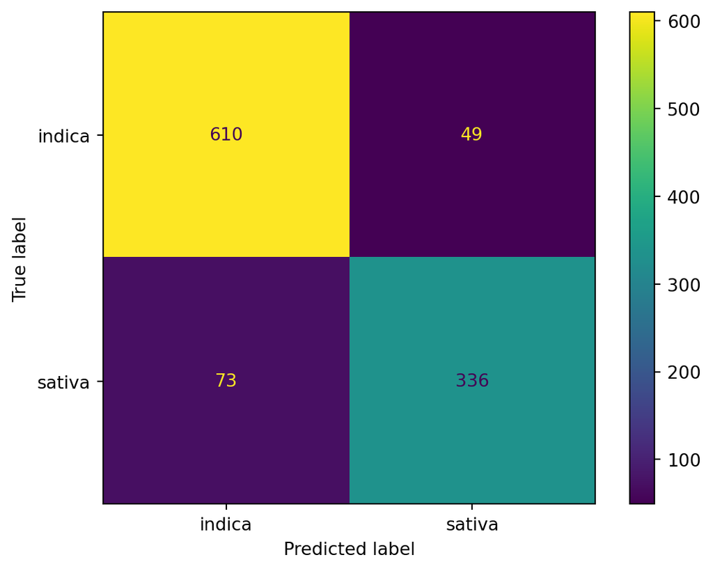

```python
ConfusionMatrixDisplay.from_estimator(lda_model_fitted, X, y)
```

## Q2: QDA

**Note**: There are no hyperparameters to tune within the QDA function (as far as we have learned), so I will simply tune the preprocessing step to determine the best scaler.

```python
qda_model = Pipeline([
    ("preprocessing", preprocessing),
    ("qda", QuadraticDiscriminantAnalysis())
])

#define parameter space
param_grid = {
    "preprocessing__scale":[StandardScaler(), MinMaxScaler()] #choice of scaler
}

#perform grid search
grid_search = GridSearchCV(
    qda_model,
    param_grid=param_grid,
    scoring="accuracy",
    cv=5
)

grid_search.fit(X, y)
print("Best accuracy score:", grid_search.best_score_)
print("Best params:", grid_search.best_params_)
```

```
Best accuracy score: 0.4390987670571717
Best params: {'preprocessing__scale': MinMaxScaler()}
```

The best QDA model is the one using a min-max scaler for the “Rating” variable due to having the largest cross-validated accuracy (0.439).

Define final best QDA model:

```python
#redefine preprocessing step with min-max scaler
preprocessing_min_max = ColumnTransformer(
    [("scale", MinMaxScaler(), ["Rating"])],
    remainder="passthrough"
    )

qda_final_model = Pipeline([
    ("preprocessing", preprocessing_min_max),
    ("qda", QuadraticDiscriminantAnalysis())
])

qda_model_fitted = qda_final_model.fit(X, y)
```

Confusion matrix:

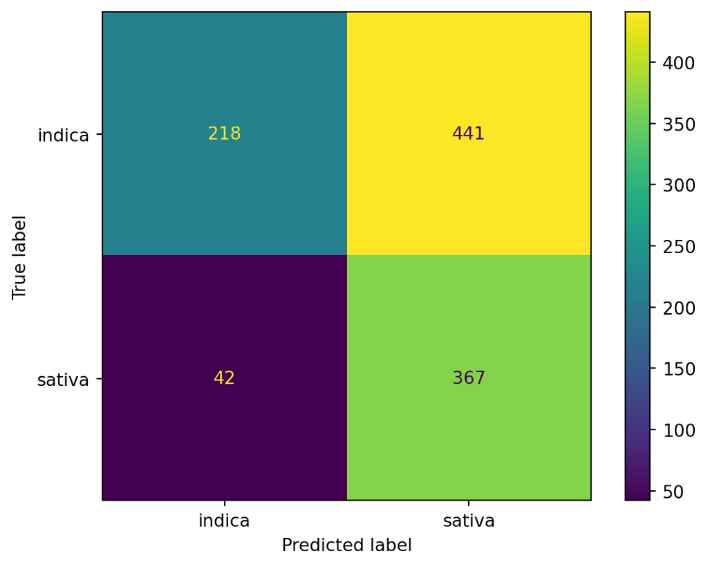

```python
ConfusionMatrixDisplay.from_estimator(qda_model_fitted, X, y)
```

## Q3: SVC

Hyperparameter tuning:

```python
#define parameter space
param_grid = {"preprocessing__scale":[StandardScaler(), MinMaxScaler()],
'svc__C': [0.01, 0.1, 1, 10, 100]}

#perform grid search
svc_model = Pipeline(
  [("preprocessing", preprocessing),
  ("svc", SVC(kernel="linear", probability=True))])

grid_search = GridSearchCV(
    svc_model,
    param_grid=param_grid,
    scoring="accuracy",
    cv=5
)

grid_search.fit(X, y)
print("Best accuracy score:", grid_search.best_score_)
print("Best params:", grid_search.best_params_)
```

```
Best accuracy score: 0.8689175551752883
Best params: {'preprocessing__scale': StandardScaler(), 'svc__C': 0.1}
```

The best SVC model is the one using a standard scaler for the “Rating” variable and a regularization strength value (C) of 0.1 due to having the largest cross-validated accuracy (0.869).

Define final best SVC model:

```python
#redefine preprocessing step with min-max scaler
svc_final_model = Pipeline([
    ("preprocessing", preprocessing),
    ("svc", SVC(kernel = "linear", probability = True, C = 0.1))])

svc_model_fitted = svc_final_model.fit(X, y)
```

Confusion matrix:

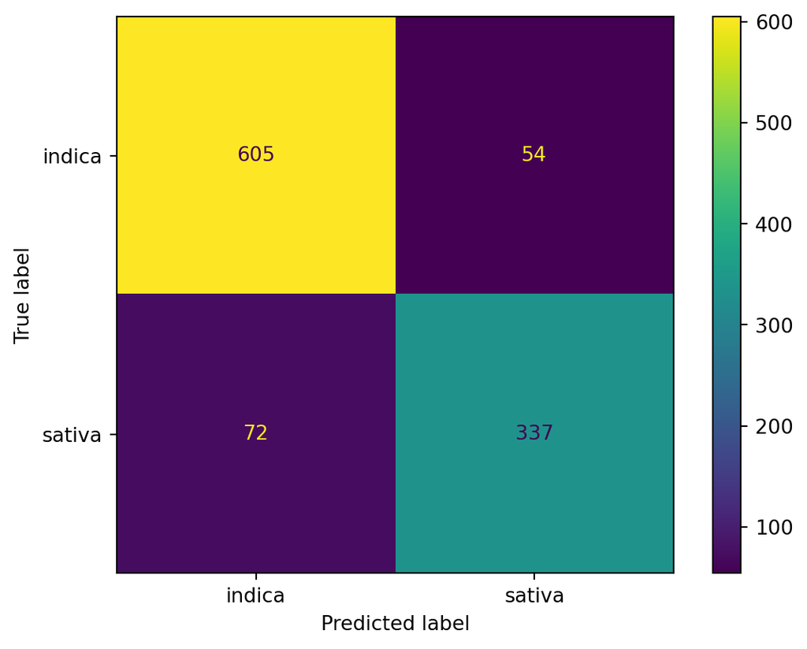

```python
ConfusionMatrixDisplay.from_estimator(svc_model_fitted, X, y)
```

## Q4: SVM

Hyperparameter tuning:

```python
#define parameter space
param_grid = {"preprocessing__scale":[StandardScaler(), MinMaxScaler()],
'svm__C': [0.01, 0.1, 1, 10, 100],
'svm__degree': [2,4,6,8,10]}

#perform grid search
svm_model = Pipeline(
  [("preprocessing", preprocessing),
  ("svm", SVC(kernel="poly", probability=True))])

grid_search = GridSearchCV(
    svm_model,
    param_grid=param_grid,
    scoring="accuracy",
    cv=5
)

grid_search.fit(X, y)
print("Best accuracy score:", grid_search.best_score_)
print("Best params:", grid_search.best_params_)
```

```
Best accuracy score: 0.8698652977052344
Best params: {'preprocessing__scale': MinMaxScaler(), 'svm__C': 1, 'svm__degree': 6}
```

The best SVM model is the one using a min-max scaler for the “Rating” variable, a regularization value (C) = 1, and degree = 6 due to having the largest cross-validated accuracy (0.87).

Define final best SVM model:

```python
#redefine preprocessing step with min-max scaler
svm_final_model = Pipeline([
    ("preprocessing", preprocessing_min_max),
    ("svm", SVC(kernel = "poly", probability = True, C = 1, degree=6))])

svm_model_fitted = svm_final_model.fit(X, y)
```

Confusion matrix:

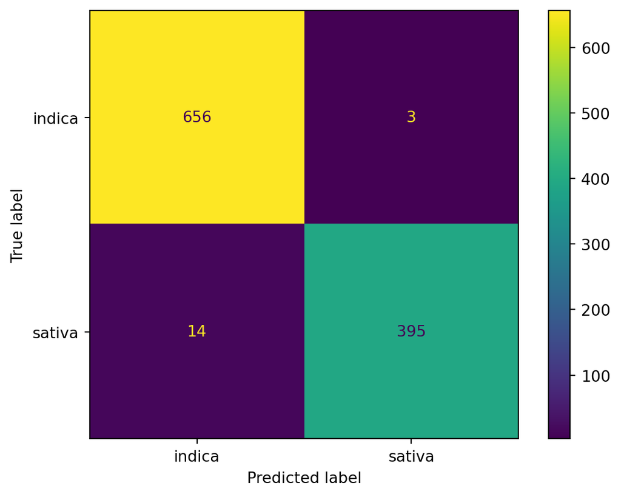

```python
ConfusionMatrixDisplay.from_estimator(svm_model_fitted, X, y)
```

# Part Two: Natural Multiclass

Full dataset:

```python
cannabis.head()
```

|  | Strain | Type | Rating | Effects | Flavor | Creative | Energetic | Tingly | Euphoric | Relaxed | ... | Ammonia | Minty | Tree | Fruit | Butter | Pineapple | Tar | Rose | Plum | Pear |
| --- | --- | --- | --- | --- | --- | --- | --- | --- | --- | --- | --- | --- | --- | --- | --- | --- | --- | --- | --- | --- | --- |
| 0 | 100-Og | hybrid | 4.0 | Creative,Energetic,Tingly,Euphoric,Relaxed | Earthy,Sweet,Citrus | 1.0 | 1.0 | 1.0 | 1.0 | 1.0 | ... | 0.0 | 0.0 | 0.0 | 0.0 | 0.0 | 0.0 | 0.0 | 0.0 | 0.0 | 0.0 |
| 1 | 98-White-Widow | hybrid | 4.7 | Relaxed,Aroused,Creative,Happy,Energetic | Flowery,Violet,Diesel | 1.0 | 1.0 | 0.0 | 0.0 | 1.0 | ... | 0.0 | 0.0 | 0.0 | 0.0 | 0.0 | 0.0 | 0.0 | 0.0 | 0.0 | 0.0 |
| 2 | 1024 | sativa | 4.4 | Uplifted,Happy,Relaxed,Energetic,Creative | Spicy/Herbal,Sage,Woody | 1.0 | 1.0 | 0.0 | 0.0 | 1.0 | ... | 0.0 | 0.0 | 0.0 | 0.0 | 0.0 | 0.0 | 0.0 | 0.0 | 0.0 | 0.0 |
| 3 | 13-Dawgs | hybrid | 4.2 | Tingly,Creative,Hungry,Relaxed,Uplifted | Apricot,Citrus,Grapefruit | 1.0 | 0.0 | 1.0 | 0.0 | 1.0 | ... | 0.0 | 0.0 | 0.0 | 0.0 | 0.0 | 0.0 | 0.0 | 0.0 | 0.0 | 0.0 |
| 4 | 24K-Gold | hybrid | 4.6 | Happy,Relaxed,Euphoric,Uplifted,Talkative | Citrus,Earthy,Orange | 0.0 | 0.0 | 0.0 | 1.0 | 1.0 | ... | 0.0 | 0.0 | 0.0 | 0.0 | 0.0 | 0.0 | 0.0 | 0.0 | 0.0 | 0.0 |

5 rows × 69 columns

Define X and y:

```python
X = cannabis.drop(['Strain', 'Type', 'Effects', 'Flavor'], axis = 1)
y = cannabis['Type']
```

```python
X.head()
```

|  | Rating | Creative | Energetic | Tingly | Euphoric | Relaxed | Aroused | Happy | Uplifted | Hungry | ... | Ammonia | Minty | Tree | Fruit | Butter | Pineapple | Tar | Rose | Plum | Pear |
| --- | --- | --- | --- | --- | --- | --- | --- | --- | --- | --- | --- | --- | --- | --- | --- | --- | --- | --- | --- | --- | --- |
| 0 | 4.0 | 1.0 | 1.0 | 1.0 | 1.0 | 1.0 | 0.0 | 0.0 | 0.0 | 0.0 | ... | 0.0 | 0.0 | 0.0 | 0.0 | 0.0 | 0.0 | 0.0 | 0.0 | 0.0 | 0.0 |
| 1 | 4.7 | 1.0 | 1.0 | 0.0 | 0.0 | 1.0 | 1.0 | 1.0 | 0.0 | 0.0 | ... | 0.0 | 0.0 | 0.0 | 0.0 | 0.0 | 0.0 | 0.0 | 0.0 | 0.0 | 0.0 |
| 2 | 4.4 | 1.0 | 1.0 | 0.0 | 0.0 | 1.0 | 0.0 | 1.0 | 1.0 | 0.0 | ... | 0.0 | 0.0 | 0.0 | 0.0 | 0.0 | 0.0 | 0.0 | 0.0 | 0.0 | 0.0 |
| 3 | 4.2 | 1.0 | 0.0 | 1.0 | 0.0 | 1.0 | 0.0 | 0.0 | 1.0 | 1.0 | ... | 0.0 | 0.0 | 0.0 | 0.0 | 0.0 | 0.0 | 0.0 | 0.0 | 0.0 | 0.0 |
| 4 | 4.6 | 0.0 | 0.0 | 0.0 | 1.0 | 1.0 | 0.0 | 1.0 | 1.0 | 0.0 | ... | 0.0 | 0.0 | 0.0 | 0.0 | 0.0 | 0.0 | 0.0 | 0.0 | 0.0 | 0.0 |

5 rows × 65 columns

```python
y.head()
```

```
0    hybrid
1    hybrid
2    sativa
3    hybrid
4    hybrid
Name: Type, dtype: object
```

## Q1: Decision tree

Tune hyperparameters:

```python
dt = DecisionTreeClassifier(random_state = 321)

paramGrid = {
    'ccp_alpha': dt.cost_complexity_pruning_path(X, y).ccp_alphas,
    'max_depth': range(1, 10+1),
    'min_samples_leaf': range(1, 10+1)
}

grid_search = GridSearchCV(dt,
                      paramGrid,
                      cv = 5,
                      scoring = 'accuracy',
                      n_jobs = -1)

grid_search.fit(X, y)
print("Best accuracy score:", grid_search.best_score_)
print("Best params:", grid_search.best_params_)
```

```
Best accuracy score: 0.6252868183189275
Best params: {'ccp_alpha': np.float64(0.0030597287744541513), 'max_depth': 3, 'min_samples_leaf': 1}
```

The best decision tree is the one using a cost complexity value of approximately 0.0031, max depth of 3, and minimum samples per leaf = 1 due to having the largest cross-validated accuracy score (0.625).

Define best tree:

```python
dt_final = DecisionTreeClassifier(ccp_alpha = 0.0030597287744541513, max_depth = 3, min_samples_leaf = 1, random_state = 321)

dt_final_fitted = dt_final.fit(X, y)
```

Display tree:

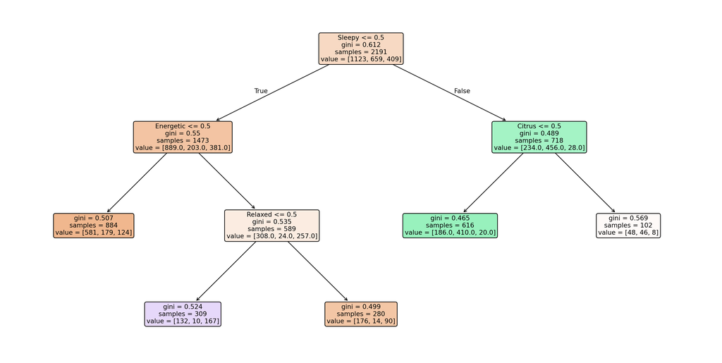

```python
plt.figure(figsize=(20,10))
plot_tree(dt_final_fitted, feature_names = X.columns, filled = True, rounded = True, fontsize = 10);
```

```python
dt_final.classes_
```

```
array(['hybrid', 'indica', 'sativa'], dtype=object)
```

Confusion matrix:

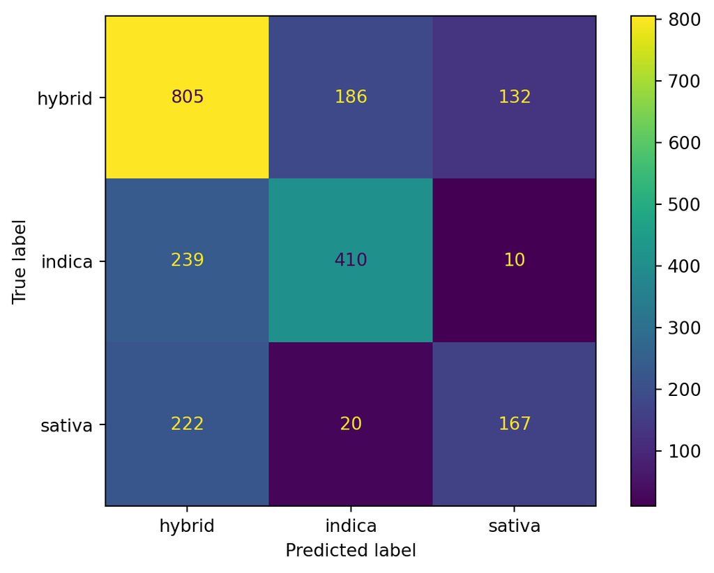

```python
ConfusionMatrixDisplay.from_estimator(dt_final_fitted, X, y)
```

## Q2: LDA

```python
lda_model2 = Pipeline([
    ("preprocessing", preprocessing),
    ("lda", LinearDiscriminantAnalysis())
])

#define parameter space
param_grid = {
    "preprocessing__scale":[StandardScaler(), MinMaxScaler()] #choice of scaler
}

#perform grid search
grid_search = GridSearchCV(
    lda_model2,
    param_grid=param_grid,
    scoring="accuracy",
    cv=5
)

grid_search.fit(X, y)
print("Best accuracy score:", grid_search.best_score_)
print("Best params:", grid_search.best_params_)
```

```
Best accuracy score: 0.6280244640683995
Best params: {'preprocessing__scale': StandardScaler()}
```

The best LDA model is the one using a standard scaler for the “Rating” variable due to having the largest cross-validated accuracy (0.628).

Define final best LDA model:

```python
lda_final_model2 = Pipeline([
    ("preprocessing", preprocessing),
    ("lda", LinearDiscriminantAnalysis())
])

lda_model2_fitted = lda_final_model2.fit(X, y)
```

Confusion matrix:

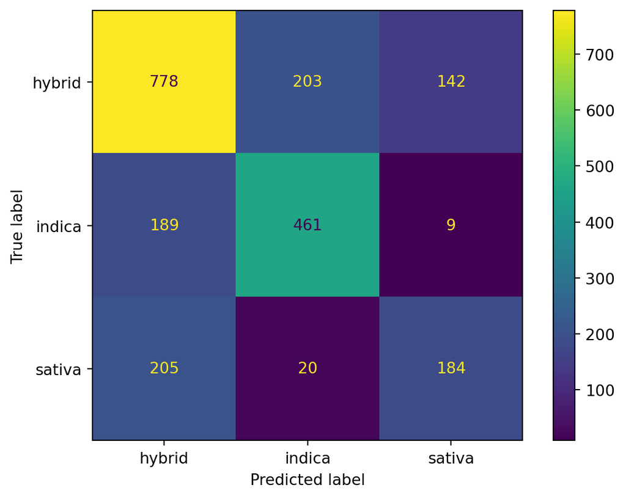

```python
ConfusionMatrixDisplay.from_estimator(lda_model2_fitted, X, y)
```

## Q2: QDA

```python
qda_model2 = Pipeline([
    ("preprocessing", preprocessing),
    ("qda", QuadraticDiscriminantAnalysis())
])

#define parameter space
param_grid = {
    "preprocessing__scale":[StandardScaler(), MinMaxScaler()] #choice of scaler
}

#perform grid search
grid_search = GridSearchCV(
    qda_model2,
    param_grid=param_grid,
    scoring="accuracy",
    cv=5
)

grid_search.fit(X, y)
print("Best accuracy score:", grid_search.best_score_)
print("Best params:", grid_search.best_params_)
```

```
Best accuracy score: 0.2355176251547207
Best params: {'preprocessing__scale': MinMaxScaler()}
```

The best QDA model is the one using a min-max scaler for the “Rating” variable due to having the largest cross-validated accuracy (0.236).

Define final best QDA model:

```python
#redefine preprocessing step with min-max scaler
preprocessing_min_max = ColumnTransformer(
    [("scale", MinMaxScaler(), ["Rating"])],
    remainder="passthrough"
    )

qda_final_model2 = Pipeline([
    ("preprocessing", preprocessing_min_max),
    ("qda", QuadraticDiscriminantAnalysis())
])

qda_model2_fitted = qda_final_model2.fit(X, y)
```

Confusion matrix:

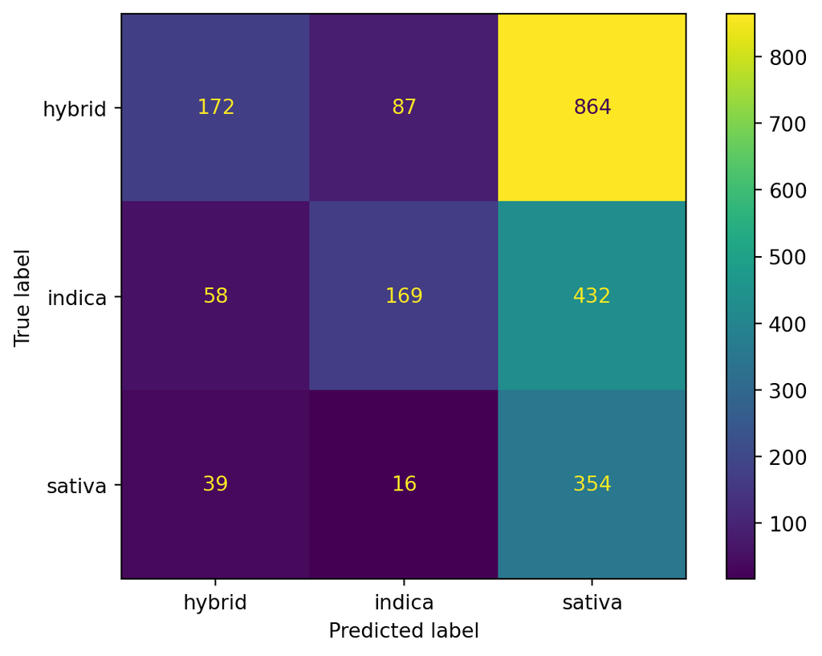

```python
ConfusionMatrixDisplay.from_estimator(qda_model2_fitted, X, y)
```

## Q2: KNN

```python
#define pipeline
KNN_model = Pipeline([
    ("preprocessing", preprocessing),
    ("knn", KNeighborsClassifier())
])

#define parameter space
param_grid = {
    "preprocessing__scale":[StandardScaler(), MinMaxScaler()], #choice of scaler
    "knn__n_neighbors": list(range(1,20+1)), #choice of k
    "knn__p": [1,2], #choice of distance (1 = Manhattan, 2 = Euclidean)
}

#perform grid search
grid_search = GridSearchCV(
    KNN_model,
    param_grid=param_grid,
    scoring="accuracy",
    cv=5
)

grid_search.fit(X, y)
print("Best accuracy score:", grid_search.best_score_)
print("Best params:", grid_search.best_params_)
```

```
Best accuracy score: 0.6111450889838882
Best params: {'knn__n_neighbors': 17, 'knn__p': 2, 'preprocessing__scale': StandardScaler()}
```

The best KNN model is the one using a standard scaler for the “Rating” variable, k = 17 neighbors, and Euclidean distance due to having the largest cross-validated accuracy (0.611).

Define best KNN model:

```python
KNN_model_final = Pipeline([
    ("preprocessing", preprocessing),
    ("knn", KNeighborsClassifier(n_neighbors=17, p = 2))
])

KNN_model_fitted = KNN_model_final.fit(X, y)
```

Confusion matrix:

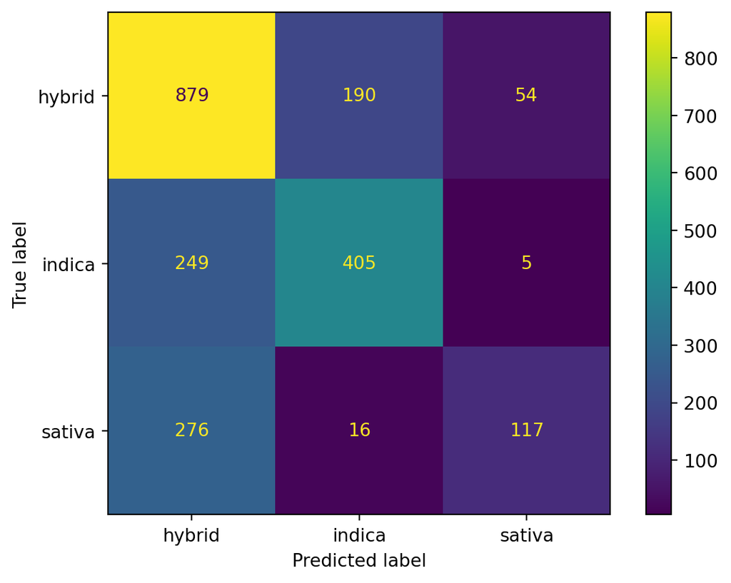

```python
ConfusionMatrixDisplay.from_estimator(KNN_model_fitted, X, y)
```

## Q3

My metrics were worse than in part one across all of my models. This makes sense as the models are not predicting a binary target variable anymore, they are predicting for a multiclass target variable. Therefore, the multiclass classification models are more prone to errors than the binary classification models as there is more than one class of the target variable that the model can incorrectly identify. According to the confusion matrices in this section, it appears that each model made the most errors distinguishing between hybrid and indica or sativa types. This is expected though, as hybrid strains of cannabis are created by crossbreeding indica and sativa plants, so they are essentially a blend of both plant’s effects. Therefore, it makes sense that the models are misclassifying hybrid types as indica or sativa types and vice versa as hybrid types are created from indica/sativa strains.

# Part Three: Multiclass from Binary

## Q1: Indica vs. Not Indica

Create new column in dataset for indica dummy variable:

```python
cannabis["indica"] = (cannabis["Type"]=="indica")*1
cannabis.head()
```

|  | Strain | Type | Rating | Effects | Flavor | Creative | Energetic | Tingly | Euphoric | Relaxed | ... | Minty | Tree | Fruit | Butter | Pineapple | Tar | Rose | Plum | Pear | indica |
| --- | --- | --- | --- | --- | --- | --- | --- | --- | --- | --- | --- | --- | --- | --- | --- | --- | --- | --- | --- | --- | --- |
| 0 | 100-Og | hybrid | 4.0 | Creative,Energetic,Tingly,Euphoric,Relaxed | Earthy,Sweet,Citrus | 1.0 | 1.0 | 1.0 | 1.0 | 1.0 | ... | 0.0 | 0.0 | 0.0 | 0.0 | 0.0 | 0.0 | 0.0 | 0.0 | 0.0 | 0 |
| 1 | 98-White-Widow | hybrid | 4.7 | Relaxed,Aroused,Creative,Happy,Energetic | Flowery,Violet,Diesel | 1.0 | 1.0 | 0.0 | 0.0 | 1.0 | ... | 0.0 | 0.0 | 0.0 | 0.0 | 0.0 | 0.0 | 0.0 | 0.0 | 0.0 | 0 |
| 2 | 1024 | sativa | 4.4 | Uplifted,Happy,Relaxed,Energetic,Creative | Spicy/Herbal,Sage,Woody | 1.0 | 1.0 | 0.0 | 0.0 | 1.0 | ... | 0.0 | 0.0 | 0.0 | 0.0 | 0.0 | 0.0 | 0.0 | 0.0 | 0.0 | 0 |
| 3 | 13-Dawgs | hybrid | 4.2 | Tingly,Creative,Hungry,Relaxed,Uplifted | Apricot,Citrus,Grapefruit | 1.0 | 0.0 | 1.0 | 0.0 | 1.0 | ... | 0.0 | 0.0 | 0.0 | 0.0 | 0.0 | 0.0 | 0.0 | 0.0 | 0.0 | 0 |
| 4 | 24K-Gold | hybrid | 4.6 | Happy,Relaxed,Euphoric,Uplifted,Talkative | Citrus,Earthy,Orange | 0.0 | 0.0 | 0.0 | 1.0 | 1.0 | ... | 0.0 | 0.0 | 0.0 | 0.0 | 0.0 | 0.0 | 0.0 | 0.0 | 0.0 | 0 |

5 rows × 70 columns

Define X and y:

```python
X = cannabis.drop(['Strain', 'Type', 'Effects', 'Flavor', 'indica'], axis = 1)
y = cannabis['indica']
```

```python
X.head()
```

|  | Rating | Creative | Energetic | Tingly | Euphoric | Relaxed | Aroused | Happy | Uplifted | Hungry | ... | Ammonia | Minty | Tree | Fruit | Butter | Pineapple | Tar | Rose | Plum | Pear |
| --- | --- | --- | --- | --- | --- | --- | --- | --- | --- | --- | --- | --- | --- | --- | --- | --- | --- | --- | --- | --- | --- |
| 0 | 4.0 | 1.0 | 1.0 | 1.0 | 1.0 | 1.0 | 0.0 | 0.0 | 0.0 | 0.0 | ... | 0.0 | 0.0 | 0.0 | 0.0 | 0.0 | 0.0 | 0.0 | 0.0 | 0.0 | 0.0 |
| 1 | 4.7 | 1.0 | 1.0 | 0.0 | 0.0 | 1.0 | 1.0 | 1.0 | 0.0 | 0.0 | ... | 0.0 | 0.0 | 0.0 | 0.0 | 0.0 | 0.0 | 0.0 | 0.0 | 0.0 | 0.0 |
| 2 | 4.4 | 1.0 | 1.0 | 0.0 | 0.0 | 1.0 | 0.0 | 1.0 | 1.0 | 0.0 | ... | 0.0 | 0.0 | 0.0 | 0.0 | 0.0 | 0.0 | 0.0 | 0.0 | 0.0 | 0.0 |
| 3 | 4.2 | 1.0 | 0.0 | 1.0 | 0.0 | 1.0 | 0.0 | 0.0 | 1.0 | 1.0 | ... | 0.0 | 0.0 | 0.0 | 0.0 | 0.0 | 0.0 | 0.0 | 0.0 | 0.0 | 0.0 |
| 4 | 4.6 | 0.0 | 0.0 | 0.0 | 1.0 | 1.0 | 0.0 | 1.0 | 1.0 | 0.0 | ... | 0.0 | 0.0 | 0.0 | 0.0 | 0.0 | 0.0 | 0.0 | 0.0 | 0.0 | 0.0 |

5 rows × 65 columns

```python
y.head()
```

```
0    0
1    0
2    0
3    0
4    0
Name: indica, dtype: int64
```

**SVC**

```python
#define parameter space
param_grid = {"preprocessing__scale":[StandardScaler(), MinMaxScaler()],
'svc__C': [0.01, 0.1, 1, 10, 100]}

#perform grid search
svc_model_ovr = Pipeline(
  [("preprocessing", preprocessing),
  ("svc", SVC(kernel="linear", probability=True))])

grid_search = GridSearchCV(
    svc_model_ovr,
    param_grid=param_grid,
    scoring="f1",
    cv=5,
    n_jobs = -1
)

grid_search.fit(X, y)
print("Best F1 score:", grid_search.best_score_)
print("Best params:", grid_search.best_params_)
```

```
Best F1 score: 0.6622757021333656
Best params: {'preprocessing__scale': StandardScaler(), 'svc__C': 0.1}
```

The best SVC model for this OvR approach is the one using a standard scaler for the “Rating” variable and a regularization strength value (C) of 0.1 due to having the largest F1 score (0.662).

Define best SVC model:

```python
svc_ovr_final = Pipeline(
  [("preprocessing", preprocessing),
  ("svc", SVC(kernel="linear", probability=True, C = 0.1))])

svc_ovr_fitted = svc_ovr_final.fit(X, y)
```

Confusion matrix:

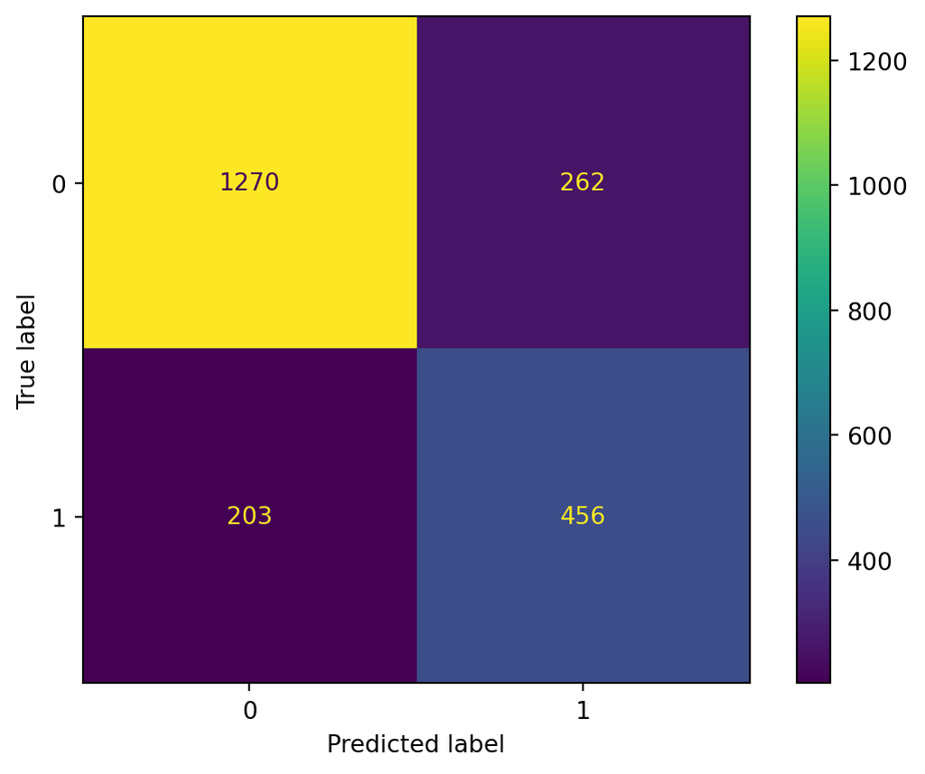

```python
ConfusionMatrixDisplay.from_estimator(svc_ovr_final, X, y)
```

**Logistic Regression**

To choose the best logistic regression model, I will determine which penalty (Ridge, Lasso, Elastic Net), regularization strength (C), and type of scaling (standard, min-max) will result in the largest F1 score.

```python
#define parameter space
param_grid = {"preprocessing__scale":[StandardScaler(), MinMaxScaler()],
"logit__penalty":["l1", "l2", "elasticnet"],
"logit__C":[0.001, 0.01, 0.1, 1, 10],
"logit__l1_ratio": [0.0, 0.25, 0.5, 0.75, 1.0]}

#perform grid search
logit_model = Pipeline(
  [("preprocessing", preprocessing),
  ("logit", LogisticRegression(solver = "saga", max_iter = 5000, random_state=321))])

grid_search = GridSearchCV(
    logit_model,
    param_grid=param_grid,
    scoring="f1",
    cv=5,
    n_jobs = -1
)

grid_search.fit(X, y)
print("Best F1 score:", grid_search.best_score_)
print("Best params:", grid_search.best_params_)
```

```
Best F1 score: 0.6589033184879624
Best params: {'logit__C': 0.1, 'logit__l1_ratio': 0.75, 'logit__penalty': 'elasticnet', 'preprocessing__scale': MinMaxScaler()}
```

The best logistic regression model for this OvR approach is the one using a min-max scaler for the “Rating” variable, an elastic net penalty with l1 ratio = 0.75, and regularization strength value (C) of 0.1 due to having the largest F1 score (0.659).

Define best logistic regression model:

```python
logit_model_final = Pipeline(
  [("preprocessing", preprocessing_min_max),
  ("logit", LogisticRegression(C = 0.1, l1_ratio=0.75, penalty="elasticnet", solver = "saga", random_state=321))])

logit_final_fitted = logit_model_final.fit(X, y)
```

Confusion matrix:

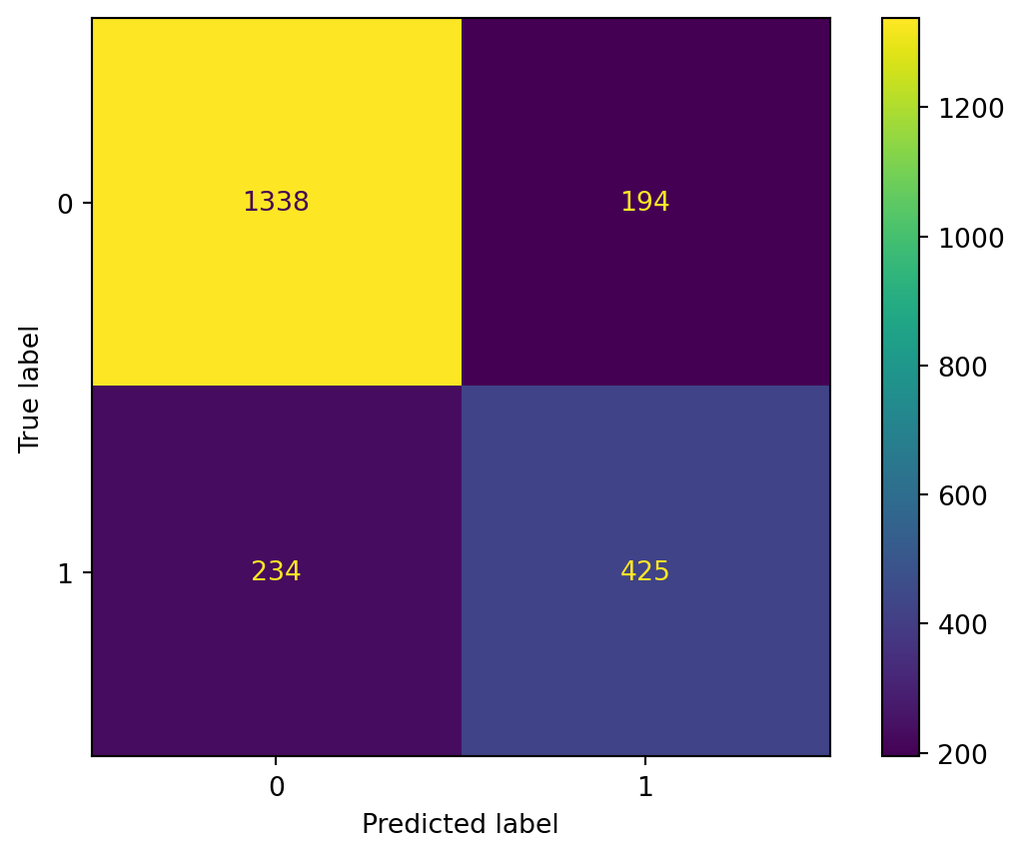

```python
ConfusionMatrixDisplay.from_estimator(logit_final_fitted, X, y)
```

## Q1: Sativa vs. Not Sativa

Create new column in dataset for sativa dummy variable:

```python
cannabis["sativa"] = (cannabis["Type"]=="sativa")*1
cannabis.head()
```

|  | Strain | Type | Rating | Effects | Flavor | Creative | Energetic | Tingly | Euphoric | Relaxed | ... | Tree | Fruit | Butter | Pineapple | Tar | Rose | Plum | Pear | indica | sativa |
| --- | --- | --- | --- | --- | --- | --- | --- | --- | --- | --- | --- | --- | --- | --- | --- | --- | --- | --- | --- | --- | --- |
| 0 | 100-Og | hybrid | 4.0 | Creative,Energetic,Tingly,Euphoric,Relaxed | Earthy,Sweet,Citrus | 1.0 | 1.0 | 1.0 | 1.0 | 1.0 | ... | 0.0 | 0.0 | 0.0 | 0.0 | 0.0 | 0.0 | 0.0 | 0.0 | 0 | 0 |
| 1 | 98-White-Widow | hybrid | 4.7 | Relaxed,Aroused,Creative,Happy,Energetic | Flowery,Violet,Diesel | 1.0 | 1.0 | 0.0 | 0.0 | 1.0 | ... | 0.0 | 0.0 | 0.0 | 0.0 | 0.0 | 0.0 | 0.0 | 0.0 | 0 | 0 |
| 2 | 1024 | sativa | 4.4 | Uplifted,Happy,Relaxed,Energetic,Creative | Spicy/Herbal,Sage,Woody | 1.0 | 1.0 | 0.0 | 0.0 | 1.0 | ... | 0.0 | 0.0 | 0.0 | 0.0 | 0.0 | 0.0 | 0.0 | 0.0 | 0 | 1 |
| 3 | 13-Dawgs | hybrid | 4.2 | Tingly,Creative,Hungry,Relaxed,Uplifted | Apricot,Citrus,Grapefruit | 1.0 | 0.0 | 1.0 | 0.0 | 1.0 | ... | 0.0 | 0.0 | 0.0 | 0.0 | 0.0 | 0.0 | 0.0 | 0.0 | 0 | 0 |
| 4 | 24K-Gold | hybrid | 4.6 | Happy,Relaxed,Euphoric,Uplifted,Talkative | Citrus,Earthy,Orange | 0.0 | 0.0 | 0.0 | 1.0 | 1.0 | ... | 0.0 | 0.0 | 0.0 | 0.0 | 0.0 | 0.0 | 0.0 | 0.0 | 0 | 0 |

5 rows × 71 columns

Define X and y:

```python
X = cannabis.drop(['Strain', 'Type', 'Effects', 'Flavor', 'indica', 'sativa'], axis = 1)
y = cannabis['sativa']
```

```python
X.head()
```

|  | Rating | Creative | Energetic | Tingly | Euphoric | Relaxed | Aroused | Happy | Uplifted | Hungry | ... | Ammonia | Minty | Tree | Fruit | Butter | Pineapple | Tar | Rose | Plum | Pear |
| --- | --- | --- | --- | --- | --- | --- | --- | --- | --- | --- | --- | --- | --- | --- | --- | --- | --- | --- | --- | --- | --- |
| 0 | 4.0 | 1.0 | 1.0 | 1.0 | 1.0 | 1.0 | 0.0 | 0.0 | 0.0 | 0.0 | ... | 0.0 | 0.0 | 0.0 | 0.0 | 0.0 | 0.0 | 0.0 | 0.0 | 0.0 | 0.0 |
| 1 | 4.7 | 1.0 | 1.0 | 0.0 | 0.0 | 1.0 | 1.0 | 1.0 | 0.0 | 0.0 | ... | 0.0 | 0.0 | 0.0 | 0.0 | 0.0 | 0.0 | 0.0 | 0.0 | 0.0 | 0.0 |
| 2 | 4.4 | 1.0 | 1.0 | 0.0 | 0.0 | 1.0 | 0.0 | 1.0 | 1.0 | 0.0 | ... | 0.0 | 0.0 | 0.0 | 0.0 | 0.0 | 0.0 | 0.0 | 0.0 | 0.0 | 0.0 |
| 3 | 4.2 | 1.0 | 0.0 | 1.0 | 0.0 | 1.0 | 0.0 | 0.0 | 1.0 | 1.0 | ... | 0.0 | 0.0 | 0.0 | 0.0 | 0.0 | 0.0 | 0.0 | 0.0 | 0.0 | 0.0 |
| 4 | 4.6 | 0.0 | 0.0 | 0.0 | 1.0 | 1.0 | 0.0 | 1.0 | 1.0 | 0.0 | ... | 0.0 | 0.0 | 0.0 | 0.0 | 0.0 | 0.0 | 0.0 | 0.0 | 0.0 | 0.0 |

5 rows × 65 columns

```python
y.head()
```

```
0    0
1    0
2    1
3    0
4    0
Name: sativa, dtype: int64
```

**SVC**

```python
#define parameter space
param_grid = {"preprocessing__scale":[StandardScaler(), MinMaxScaler()],
'svc__C': [0.01, 0.1, 1, 10, 100]}

#perform grid search
svc_model_ovr2 = Pipeline(
  [("preprocessing", preprocessing),
  ("svc", SVC(kernel="linear", probability=True))])

grid_search = GridSearchCV(
    svc_model_ovr2,
    param_grid=param_grid,
    scoring="f1",
    cv=5,
    n_jobs = -1
)

grid_search.fit(X, y)
print("Best F1 score:", grid_search.best_score_)
print("Best params:", grid_search.best_params_)
```

```
Best F1 score: 0.2961624210616146
Best params: {'preprocessing__scale': MinMaxScaler(), 'svc__C': 100}
```

The best SVC model for this OvR approach is the one using a min-max scaler for the “Rating” variable and a regularization strength value (C) of 100 due to having the largest F1 score (0.296).

Define best SVC model:

```python
svc_ovr2_final = Pipeline(
  [("preprocessing", preprocessing_min_max),
  ("svc", SVC(kernel="linear", probability=True, C = 100))])

svc_ovr2_fitted = svc_ovr2_final.fit(X, y)
```

Confusion matrix:

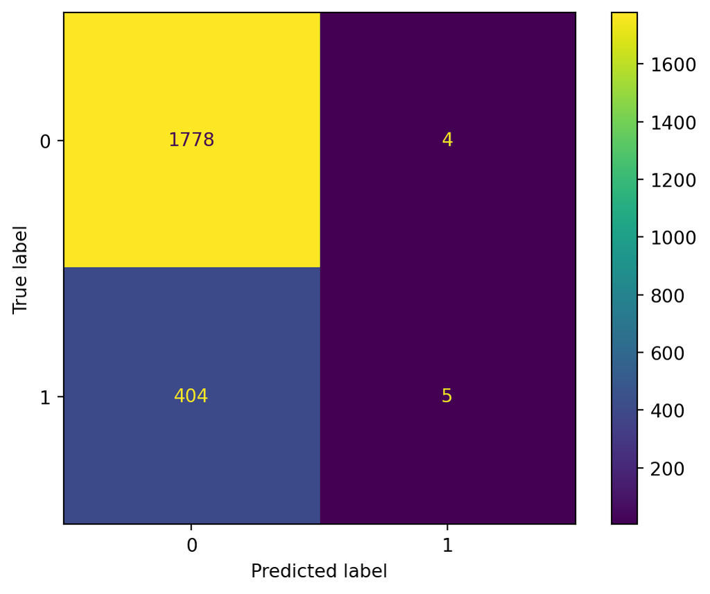

```python
ConfusionMatrixDisplay.from_estimator(svc_ovr2_final, X, y)
```

**Logistic Regression**

```python
#define parameter space
param_grid = {"preprocessing__scale":[StandardScaler(), MinMaxScaler()],
"logit__penalty":["l1", "l2", "elasticnet"],
"logit__C":[0.001, 0.01, 0.1, 1, 10],
"logit__l1_ratio": [0.0, 0.25, 0.5, 0.75, 1.0]}

#perform grid search
logit_model2 = Pipeline(
  [("preprocessing", preprocessing),
  ("logit", LogisticRegression(solver = "saga", max_iter = 5000, random_state=321))])

grid_search = GridSearchCV(
    logit_model2,
    param_grid=param_grid,
    scoring="f1",
    cv=5,
    n_jobs = -1
)

grid_search.fit(X, y)
print("Best F1 score:", grid_search.best_score_)
print("Best params:", grid_search.best_params_)
```

```
Best F1 score: 0.40506587889109
Best params: {'logit__C': 10, 'logit__l1_ratio': 0.0, 'logit__penalty': 'l2', 'preprocessing__scale': StandardScaler()}
```

The best logistic regression model for this OvR approach is the one using a standard scaler for the “Rating” variable, a ridge penalty with a regularization strength value (C) of 10 due to having the largest F1 score (0.405).

Define best logistic regression model:

```python
logit_model2_final = Pipeline(
  [("preprocessing", preprocessing),
  ("logit", LogisticRegression(C = 10, penalty="l2", solver = "saga", random_state=321, max_iter=5000))])

logit_final2_fitted = logit_model2_final.fit(X, y)
```

Confusion matrix:

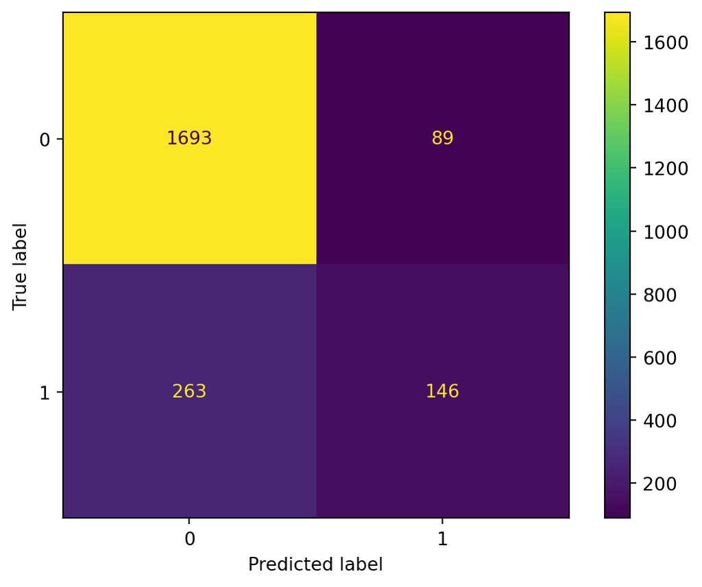

```python
ConfusionMatrixDisplay.from_estimator(logit_final2_fitted, X, y)
```

## Q1: Hybrid vs. Not Hybrid

Create new column in dataset for hybrid dummy variable:

```python
cannabis["hybrid"] = (cannabis["Type"]=="hybrid")*1
cannabis.head()
```

|  | Strain | Type | Rating | Effects | Flavor | Creative | Energetic | Tingly | Euphoric | Relaxed | ... | Fruit | Butter | Pineapple | Tar | Rose | Plum | Pear | indica | sativa | hybrid |
| --- | --- | --- | --- | --- | --- | --- | --- | --- | --- | --- | --- | --- | --- | --- | --- | --- | --- | --- | --- | --- | --- |
| 0 | 100-Og | hybrid | 4.0 | Creative,Energetic,Tingly,Euphoric,Relaxed | Earthy,Sweet,Citrus | 1.0 | 1.0 | 1.0 | 1.0 | 1.0 | ... | 0.0 | 0.0 | 0.0 | 0.0 | 0.0 | 0.0 | 0.0 | 0 | 0 | 1 |
| 1 | 98-White-Widow | hybrid | 4.7 | Relaxed,Aroused,Creative,Happy,Energetic | Flowery,Violet,Diesel | 1.0 | 1.0 | 0.0 | 0.0 | 1.0 | ... | 0.0 | 0.0 | 0.0 | 0.0 | 0.0 | 0.0 | 0.0 | 0 | 0 | 1 |
| 2 | 1024 | sativa | 4.4 | Uplifted,Happy,Relaxed,Energetic,Creative | Spicy/Herbal,Sage,Woody | 1.0 | 1.0 | 0.0 | 0.0 | 1.0 | ... | 0.0 | 0.0 | 0.0 | 0.0 | 0.0 | 0.0 | 0.0 | 0 | 1 | 0 |
| 3 | 13-Dawgs | hybrid | 4.2 | Tingly,Creative,Hungry,Relaxed,Uplifted | Apricot,Citrus,Grapefruit | 1.0 | 0.0 | 1.0 | 0.0 | 1.0 | ... | 0.0 | 0.0 | 0.0 | 0.0 | 0.0 | 0.0 | 0.0 | 0 | 0 | 1 |
| 4 | 24K-Gold | hybrid | 4.6 | Happy,Relaxed,Euphoric,Uplifted,Talkative | Citrus,Earthy,Orange | 0.0 | 0.0 | 0.0 | 1.0 | 1.0 | ... | 0.0 | 0.0 | 0.0 | 0.0 | 0.0 | 0.0 | 0.0 | 0 | 0 | 1 |

5 rows × 72 columns

Define X and y:

```python
X = cannabis.drop(['Strain', 'Type', 'Effects', 'Flavor', 'indica', 'sativa', 'hybrid'], axis = 1)
y = cannabis['hybrid']
```

```python
X.head()
```

|  | Rating | Creative | Energetic | Tingly | Euphoric | Relaxed | Aroused | Happy | Uplifted | Hungry | ... | Ammonia | Minty | Tree | Fruit | Butter | Pineapple | Tar | Rose | Plum | Pear |
| --- | --- | --- | --- | --- | --- | --- | --- | --- | --- | --- | --- | --- | --- | --- | --- | --- | --- | --- | --- | --- | --- |
| 0 | 4.0 | 1.0 | 1.0 | 1.0 | 1.0 | 1.0 | 0.0 | 0.0 | 0.0 | 0.0 | ... | 0.0 | 0.0 | 0.0 | 0.0 | 0.0 | 0.0 | 0.0 | 0.0 | 0.0 | 0.0 |
| 1 | 4.7 | 1.0 | 1.0 | 0.0 | 0.0 | 1.0 | 1.0 | 1.0 | 0.0 | 0.0 | ... | 0.0 | 0.0 | 0.0 | 0.0 | 0.0 | 0.0 | 0.0 | 0.0 | 0.0 | 0.0 |
| 2 | 4.4 | 1.0 | 1.0 | 0.0 | 0.0 | 1.0 | 0.0 | 1.0 | 1.0 | 0.0 | ... | 0.0 | 0.0 | 0.0 | 0.0 | 0.0 | 0.0 | 0.0 | 0.0 | 0.0 | 0.0 |
| 3 | 4.2 | 1.0 | 0.0 | 1.0 | 0.0 | 1.0 | 0.0 | 0.0 | 1.0 | 1.0 | ... | 0.0 | 0.0 | 0.0 | 0.0 | 0.0 | 0.0 | 0.0 | 0.0 | 0.0 | 0.0 |
| 4 | 4.6 | 0.0 | 0.0 | 0.0 | 1.0 | 1.0 | 0.0 | 1.0 | 1.0 | 0.0 | ... | 0.0 | 0.0 | 0.0 | 0.0 | 0.0 | 0.0 | 0.0 | 0.0 | 0.0 | 0.0 |

5 rows × 65 columns

```python
y.head()
```

```
0    1
1    1
2    0
3    1
4    1
Name: hybrid, dtype: int64
```

**SVC**

```python
#define parameter space
param_grid = {"preprocessing__scale":[StandardScaler(), MinMaxScaler()],
'svc__C': [0.01, 0.1, 1, 10, 100]}

#perform grid search
svc_model_ovr3 = Pipeline(
  [("preprocessing", preprocessing),
  ("svc", SVC(kernel="linear", probability=True))])

grid_search = GridSearchCV(
    svc_model_ovr3,
    param_grid=param_grid,
    scoring="f1",
    cv=5,
    n_jobs = -1
)

grid_search.fit(X, y)
print("Best F1 score:", grid_search.best_score_)
print("Best params:", grid_search.best_params_)
```

```
Best F1 score: 0.6844083037369331
Best params: {'preprocessing__scale': StandardScaler(), 'svc__C': 0.1}
```

The best SVC model for this OvR approach is the one using a standard scaler for the “Rating” variable and a regularization strength value (C) of 0.1 due to having the largest F1 score (0.684).

Define best SVC model:

```python
svc_ovr3_final = Pipeline(
  [("preprocessing", preprocessing),
  ("svc", SVC(kernel="linear", probability=True, C = 0.1))])

svc_ovr3_fitted = svc_ovr3_final.fit(X, y)
```

Confusion matrix:

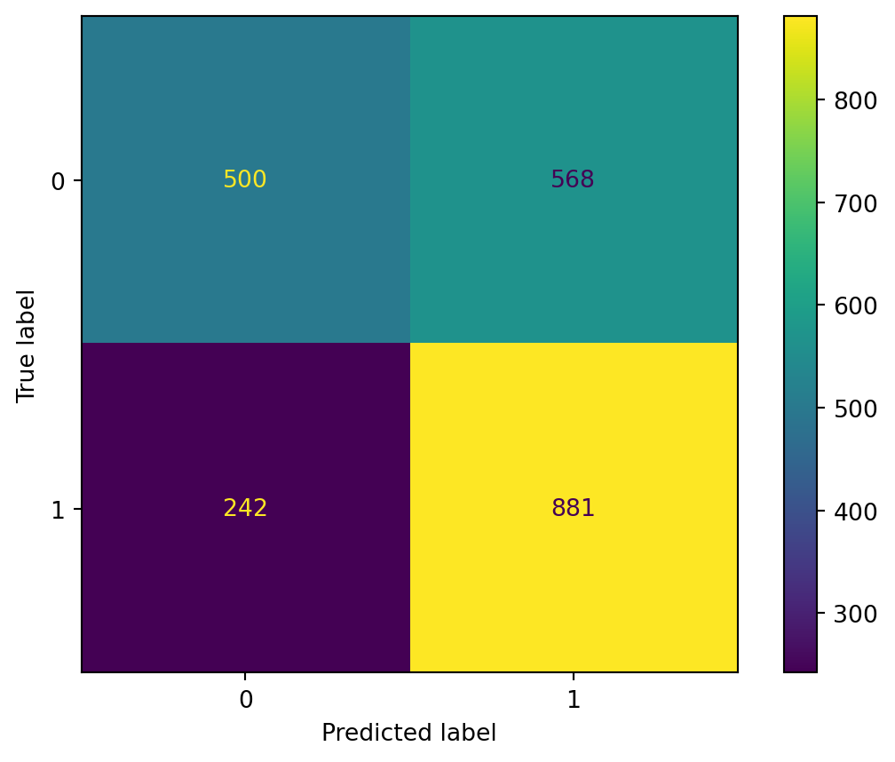

```python
ConfusionMatrixDisplay.from_estimator(svc_ovr3_final, X, y)
```

**Logistic Regression**

```python
#define parameter space
param_grid = {"preprocessing__scale":[StandardScaler(), MinMaxScaler()],
"logit__penalty":["l1", "l2", "elasticnet"],
"logit__C":[0.001, 0.01, 0.1, 1, 10],
"logit__l1_ratio": [0.0, 0.25, 0.5, 0.75, 1.0]}

#perform grid search
logit_model3 = Pipeline(
  [("preprocessing", preprocessing),
  ("logit", LogisticRegression(solver = "saga", max_iter = 5000, random_state=321))])

grid_search = GridSearchCV(
    logit_model3,
    param_grid=param_grid,
    scoring="f1",
    cv=5,
    n_jobs = -1
)

grid_search.fit(X, y)
print("Best F1 score:", grid_search.best_score_)
print("Best params:", grid_search.best_params_)
```

```
Best F1 score: 0.6908423326077429
Best params: {'logit__C': 0.001, 'logit__l1_ratio': 0.0, 'logit__penalty': 'l2', 'preprocessing__scale': MinMaxScaler()}
```

The best logistic regression model for this OvR approach is the one using a min-max scaler for the “Rating” variable and a ridge penalty with a regularization strength value (C) of 0.001 due to having the largest F1 score (0.691).

Define best logistic regression model:

```python
logit_model3_final = Pipeline(
  [("preprocessing", preprocessing_min_max),
  ("logit", LogisticRegression(C = 0.001, penalty="l2", solver = "saga", random_state=321, max_iter=5000))])

logit_final3_fitted = logit_model3_final.fit(X, y)
```

Confusion matrix:

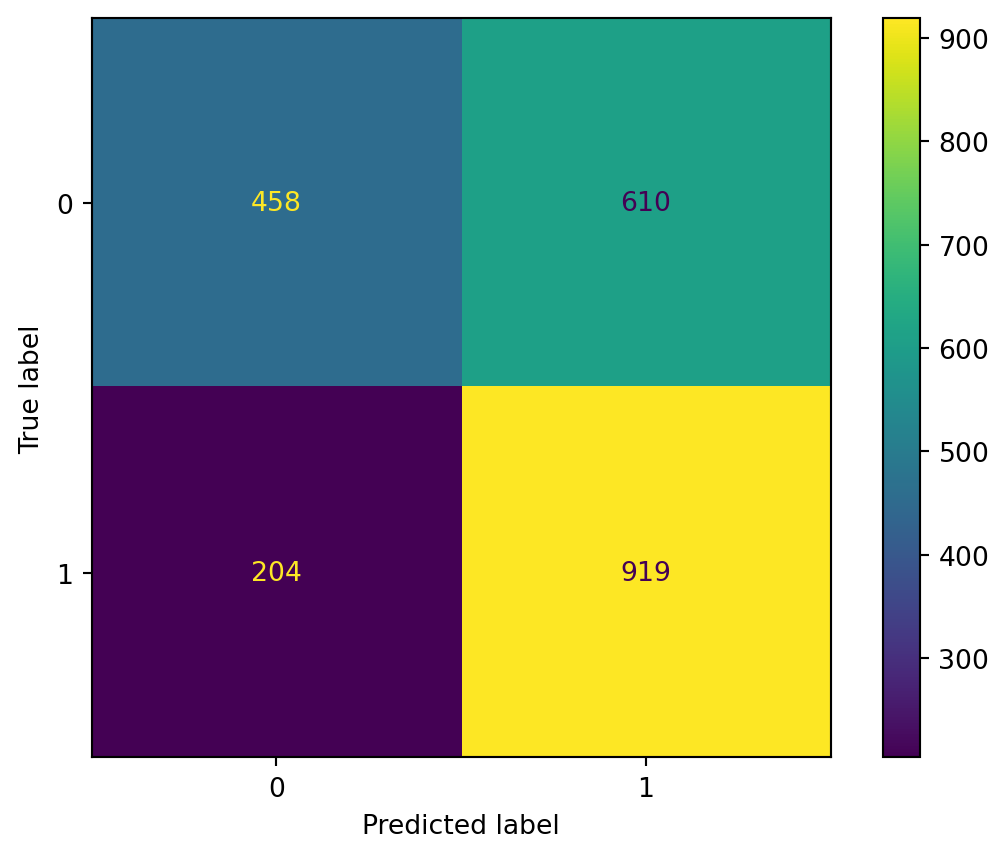

```python
ConfusionMatrixDisplay.from_estimator(logit_final3_fitted, X, y)
```

## Q2

The hybrid vs. not hybrid specification for the logistic regression model performed the best due to having the largest F1 score. The sativa vs. not sativa specification for the SVC model performed the worst due to having the smallest F1 score. It makes intuitive sense that logistic model was best able to identify hybrid types from non-hybrid types because it is more difficult to differentiate indica or sativa types from hybrid types than hybrid types from pure indica or sativa types. Hybrid strains are more easily differentiated from indica/sativa types since hybrid strains are a mix of indica/sativa while indica and sativa are purely single strain types. When we use indica and sativa as the target variables instead, it makes sense that the model has a more difficult time identifying the target class as indica or sativa due to the “rest” component of these models consisting of a mix of both strains (hybrid). Also, the logistic model generally does a better job with identifying the probability of an observation belonging to a target class, while SVC’s goal is to maximize the margin between two classes (better for differentiation). So, it makes sense that the logistic regression model did better than the SVC model in distinguishing the target class from the rest of the classes.

## Q3: Indica vs. Sativa

Reduce dataset to only indica and sativa types:

```python
cannabis_ind_sat = cannabis[(cannabis["Type"] == "indica") | (cannabis["Type"] == "sativa")]
```

Define X and y:

```python
X = cannabis_ind_sat.drop(['Strain', 'Type', 'Effects', 'Flavor', 'indica', 'sativa', 'hybrid'], axis = 1)
y = cannabis_ind_sat['Type']
```

```python
X.head()
```

|  | Rating | Creative | Energetic | Tingly | Euphoric | Relaxed | Aroused | Happy | Uplifted | Hungry | ... | Ammonia | Minty | Tree | Fruit | Butter | Pineapple | Tar | Rose | Plum | Pear |
| --- | --- | --- | --- | --- | --- | --- | --- | --- | --- | --- | --- | --- | --- | --- | --- | --- | --- | --- | --- | --- | --- |
| 2 | 4.4 | 1.0 | 1.0 | 0.0 | 0.0 | 1.0 | 0.0 | 1.0 | 1.0 | 0.0 | ... | 0.0 | 0.0 | 0.0 | 0.0 | 0.0 | 0.0 | 0.0 | 0.0 | 0.0 | 0.0 |
| 7 | 4.2 | 0.0 | 0.0 | 0.0 | 1.0 | 1.0 | 0.0 | 1.0 | 1.0 | 0.0 | ... | 0.0 | 0.0 | 0.0 | 0.0 | 0.0 | 0.0 | 0.0 | 0.0 | 0.0 | 0.0 |
| 8 | 4.6 | 0.0 | 0.0 | 0.0 | 0.0 | 1.0 | 0.0 | 1.0 | 1.0 | 0.0 | ... | 0.0 | 0.0 | 0.0 | 0.0 | 0.0 | 0.0 | 0.0 | 0.0 | 0.0 | 0.0 |
| 9 | 4.4 | 0.0 | 0.0 | 1.0 | 1.0 | 1.0 | 0.0 | 1.0 | 1.0 | 0.0 | ... | 0.0 | 0.0 | 0.0 | 0.0 | 0.0 | 0.0 | 0.0 | 0.0 | 0.0 | 0.0 |
| 12 | 4.4 | 0.0 | 0.0 | 0.0 | 1.0 | 1.0 | 1.0 | 0.0 | 1.0 | 0.0 | ... | 0.0 | 0.0 | 0.0 | 0.0 | 0.0 | 0.0 | 0.0 | 0.0 | 0.0 | 0.0 |

5 rows × 65 columns

```python
y.head()
```

```
2     sativa
7     indica
8     sativa
9     indica
12    indica
Name: Type, dtype: object
```

**SVC**

```python
#define parameter space
param_grid = {"preprocessing__scale":[StandardScaler(), MinMaxScaler()],
'svc__C': [0.01, 0.1, 1, 10, 100]}

#perform grid search
svc_model_ovo = Pipeline(
  [("preprocessing", preprocessing),
  ("svc", SVC(kernel="linear", probability=True))])

grid_search = GridSearchCV(
    svc_model_ovo,
    param_grid=param_grid,
    scoring="accuracy",
    cv=5,
    n_jobs = -1
)

grid_search.fit(X, y)
print("Best accuracy score:", grid_search.best_score_)
print("Best params:", grid_search.best_params_)
```

```
Best accuracy score: 0.8689175551752883
Best params: {'preprocessing__scale': StandardScaler(), 'svc__C': 0.1}
```

The best SVC model for this OvR approach is the one using a standard scaler for the “Rating” variable and a regularization strength value (C) of 0.1 due to having the largest accuracy score (0.869).

Define best SVC model:

```python
svc_ovo_final = Pipeline(
  [("preprocessing", preprocessing),
  ("svc", SVC(kernel="linear", probability=True, C = 0.1))])

svc_ovo_fitted = svc_ovo_final.fit(X, y)
```

Confusion matrix:

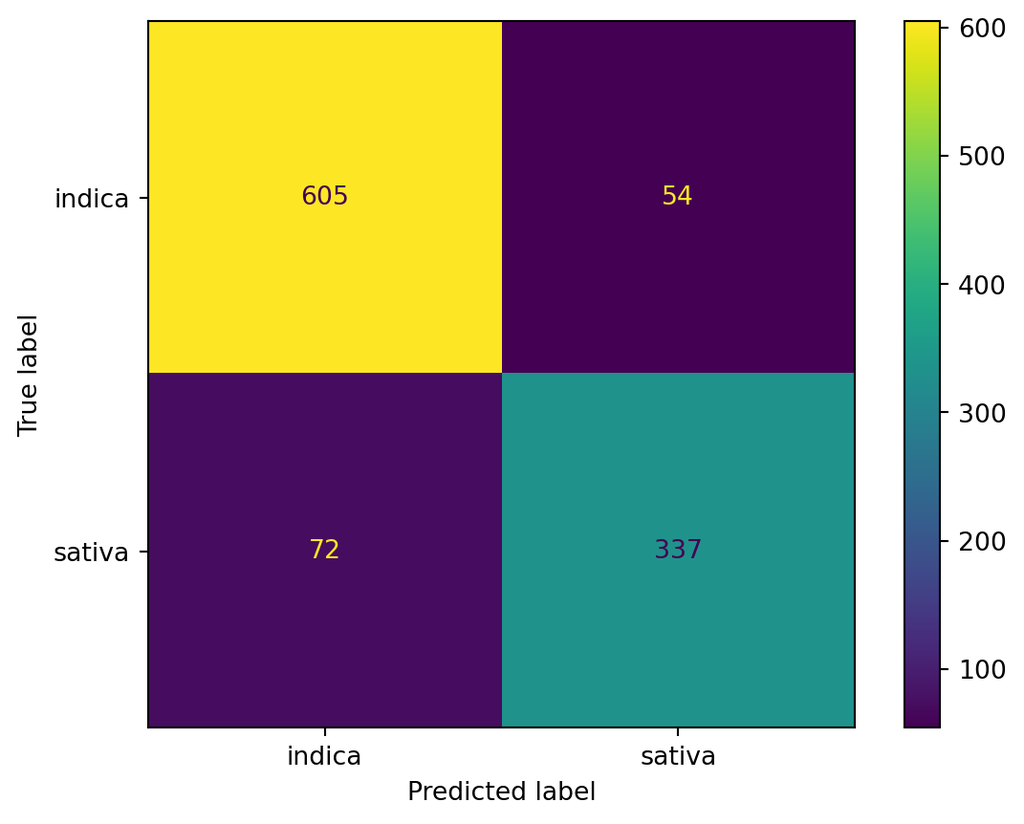

```python
ConfusionMatrixDisplay.from_estimator(svc_ovo_fitted, X, y)
```

**Logistic Regression**

```python
#define parameter space
param_grid = {"preprocessing__scale":[StandardScaler(), MinMaxScaler()],
"logit__penalty":["l1", "l2", "elasticnet"],
"logit__C":[0.001, 0.01, 0.1, 1, 10],
"logit__l1_ratio": [0.0, 0.25, 0.5, 0.75, 1.0]}

#perform grid search
logit_model_ovo = Pipeline(
  [("preprocessing", preprocessing),
  ("logit", LogisticRegression(solver = "saga", max_iter = 5000, random_state=321))])

grid_search = GridSearchCV(
    logit_model_ovo,
    param_grid=param_grid,
    scoring="accuracy",
    cv=5,
    n_jobs = -1
)

grid_search.fit(X, y)
print("Best accuracy score:", grid_search.best_score_)
print("Best params:", grid_search.best_params_)
```

```
Best accuracy score: 0.8707867140537932
Best params: {'logit__C': 0.1, 'logit__l1_ratio': 0.0, 'logit__penalty': 'l2', 'preprocessing__scale': StandardScaler()}
```

The best logistic regression model for this OvR approach is the one using a standard scaler for the “Rating” variable and a ridge penalty with a regularization strength value (C) of 0.1 due to having the largest accuracy score (0.871).

Define best logistic regression model:

```python
logit_ovo_final = Pipeline(
  [("preprocessing", preprocessing),
  ("logit", LogisticRegression(C = 0.1, penalty="l2", solver = "saga", random_state=321, max_iter=5000))])

logit_ovo_fitted = logit_ovo_final.fit(X, y)
```

Confusion matrix:

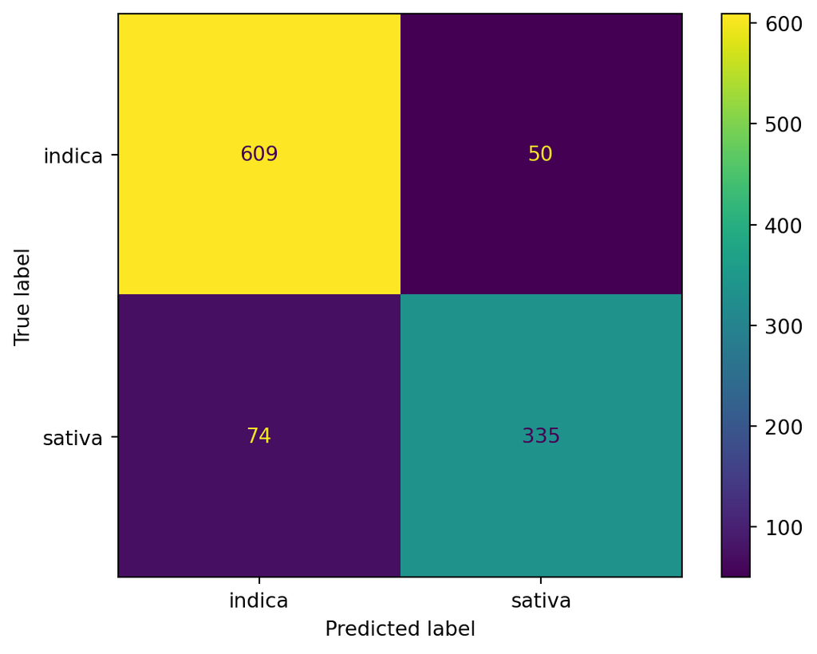

```python
ConfusionMatrixDisplay.from_estimator(logit_ovo_fitted, X, y)
```

## Q3: Indica vs. Hybrid

Reduce dataset to only indica and hybrid types:

```python
cannabis_ind_hyb = cannabis[(cannabis["Type"] == "indica") | (cannabis["Type"] == "hybrid")]
cannabis_ind_hyb.head()
```

|  | Strain | Type | Rating | Effects | Flavor | Creative | Energetic | Tingly | Euphoric | Relaxed | ... | Fruit | Butter | Pineapple | Tar | Rose | Plum | Pear | indica | sativa | hybrid |
| --- | --- | --- | --- | --- | --- | --- | --- | --- | --- | --- | --- | --- | --- | --- | --- | --- | --- | --- | --- | --- | --- |
| 0 | 100-Og | hybrid | 4.0 | Creative,Energetic,Tingly,Euphoric,Relaxed | Earthy,Sweet,Citrus | 1.0 | 1.0 | 1.0 | 1.0 | 1.0 | ... | 0.0 | 0.0 | 0.0 | 0.0 | 0.0 | 0.0 | 0.0 | 0 | 0 | 1 |
| 1 | 98-White-Widow | hybrid | 4.7 | Relaxed,Aroused,Creative,Happy,Energetic | Flowery,Violet,Diesel | 1.0 | 1.0 | 0.0 | 0.0 | 1.0 | ... | 0.0 | 0.0 | 0.0 | 0.0 | 0.0 | 0.0 | 0.0 | 0 | 0 | 1 |
| 3 | 13-Dawgs | hybrid | 4.2 | Tingly,Creative,Hungry,Relaxed,Uplifted | Apricot,Citrus,Grapefruit | 1.0 | 0.0 | 1.0 | 0.0 | 1.0 | ... | 0.0 | 0.0 | 0.0 | 0.0 | 0.0 | 0.0 | 0.0 | 0 | 0 | 1 |
| 4 | 24K-Gold | hybrid | 4.6 | Happy,Relaxed,Euphoric,Uplifted,Talkative | Citrus,Earthy,Orange | 0.0 | 0.0 | 0.0 | 1.0 | 1.0 | ... | 0.0 | 0.0 | 0.0 | 0.0 | 0.0 | 0.0 | 0.0 | 0 | 0 | 1 |
| 6 | 3-Kings | hybrid | 4.4 | Relaxed,Euphoric,Happy,Uplifted,Hungry | Earthy,Sweet,Pungent | 0.0 | 0.0 | 0.0 | 1.0 | 1.0 | ... | 0.0 | 0.0 | 0.0 | 0.0 | 0.0 | 0.0 | 0.0 | 0 | 0 | 1 |

5 rows × 72 columns

Define X and y:

```python
X = cannabis_ind_hyb.drop(['Strain', 'Type', 'Effects', 'Flavor', 'indica', 'sativa', 'hybrid'], axis = 1)
y = cannabis_ind_hyb['Type']
```

```python
X.head()
```

|  | Rating | Creative | Energetic | Tingly | Euphoric | Relaxed | Aroused | Happy | Uplifted | Hungry | ... | Ammonia | Minty | Tree | Fruit | Butter | Pineapple | Tar | Rose | Plum | Pear |
| --- | --- | --- | --- | --- | --- | --- | --- | --- | --- | --- | --- | --- | --- | --- | --- | --- | --- | --- | --- | --- | --- |
| 0 | 4.0 | 1.0 | 1.0 | 1.0 | 1.0 | 1.0 | 0.0 | 0.0 | 0.0 | 0.0 | ... | 0.0 | 0.0 | 0.0 | 0.0 | 0.0 | 0.0 | 0.0 | 0.0 | 0.0 | 0.0 |
| 1 | 4.7 | 1.0 | 1.0 | 0.0 | 0.0 | 1.0 | 1.0 | 1.0 | 0.0 | 0.0 | ... | 0.0 | 0.0 | 0.0 | 0.0 | 0.0 | 0.0 | 0.0 | 0.0 | 0.0 | 0.0 |
| 3 | 4.2 | 1.0 | 0.0 | 1.0 | 0.0 | 1.0 | 0.0 | 0.0 | 1.0 | 1.0 | ... | 0.0 | 0.0 | 0.0 | 0.0 | 0.0 | 0.0 | 0.0 | 0.0 | 0.0 | 0.0 |
| 4 | 4.6 | 0.0 | 0.0 | 0.0 | 1.0 | 1.0 | 0.0 | 1.0 | 1.0 | 0.0 | ... | 0.0 | 0.0 | 0.0 | 0.0 | 0.0 | 0.0 | 0.0 | 0.0 | 0.0 | 0.0 |
| 6 | 4.4 | 0.0 | 0.0 | 0.0 | 1.0 | 1.0 | 0.0 | 1.0 | 1.0 | 1.0 | ... | 0.0 | 0.0 | 0.0 | 0.0 | 0.0 | 0.0 | 0.0 | 0.0 | 0.0 | 0.0 |

5 rows × 65 columns

```python
y.head()
```

```
0    hybrid
1    hybrid
3    hybrid
4    hybrid
6    hybrid
Name: Type, dtype: object
```

**SVC**

```python
#define parameter space
param_grid = {"preprocessing__scale":[StandardScaler(), MinMaxScaler()],
'svc__C': [0.01, 0.1, 1, 10, 100]}

#perform grid search
svc_model_ovo2 = Pipeline(
  [("preprocessing", preprocessing),
  ("svc", SVC(kernel="linear", probability=True))])

grid_search = GridSearchCV(
    svc_model_ovo2,
    param_grid=param_grid,
    scoring="accuracy",
    cv=5,
    n_jobs = -1
)

grid_search.fit(X, y)
print("Best accuracy score:", grid_search.best_score_)
print("Best params:", grid_search.best_params_)
```

```
Best accuracy score: 0.7575834828313347
Best params: {'preprocessing__scale': StandardScaler(), 'svc__C': 10}
```

The best SVC model for this OvR approach is the one using a standard scaler for the “Rating” variable and a regularization strength value (C) of 10 due to having the largest accuracy score (0.758).

Define best SVC model:

```python
svc_ovo2_final = Pipeline(
  [("preprocessing", preprocessing),
  ("svc", SVC(kernel="linear", probability=True, C = 10))])

svc_ovo2_fitted = svc_ovo2_final.fit(X, y)
```

Confusion matrix:

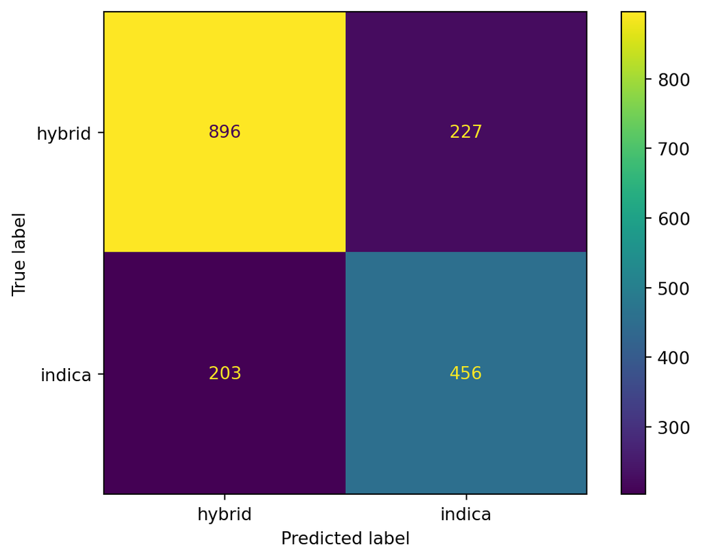

```python
ConfusionMatrixDisplay.from_estimator(svc_ovo2_fitted, X, y)
```

**Logistic Regression**

```python
#define parameter space
param_grid = {"preprocessing__scale":[StandardScaler(), MinMaxScaler()],
"logit__penalty":["l1", "l2", "elasticnet"],
"logit__C":[0.001, 0.01, 0.1, 1, 10],
"logit__l1_ratio": [0.0, 0.25, 0.5, 0.75, 1.0]}

#perform grid search
logit_model_ovo2 = Pipeline(
  [("preprocessing", preprocessing),
  ("logit", LogisticRegression(solver = "saga", max_iter = 5000, random_state=321))])

grid_search = GridSearchCV(
    logit_model_ovo2,
    param_grid=param_grid,
    scoring="accuracy",
    cv=5,
    n_jobs = -1
)

grid_search.fit(X, y)
print("Best accuracy score:", grid_search.best_score_)
print("Best params:", grid_search.best_params_)
```

```
Best accuracy score: 0.7626365152802694
Best params: {'logit__C': 0.1, 'logit__l1_ratio': 0.0, 'logit__penalty': 'l2', 'preprocessing__scale': MinMaxScaler()}
```

The best logistic regression model for this OvR approach is the one using a min-max scaler for the “Rating” variable and a ridge penalty with a regularization strength value (C) of 0.1 due to having the largest accuracy score (0.763).

Define best logistic regression model:

```python
logit_ovo2_final = Pipeline(
  [("preprocessing", preprocessing_min_max),
  ("logit", LogisticRegression(C = 0.1, penalty="l2", solver = "saga", random_state=321, max_iter=5000))])

logit_ovo2_fitted = logit_ovo2_final.fit(X, y)
```

Confusion matrix:

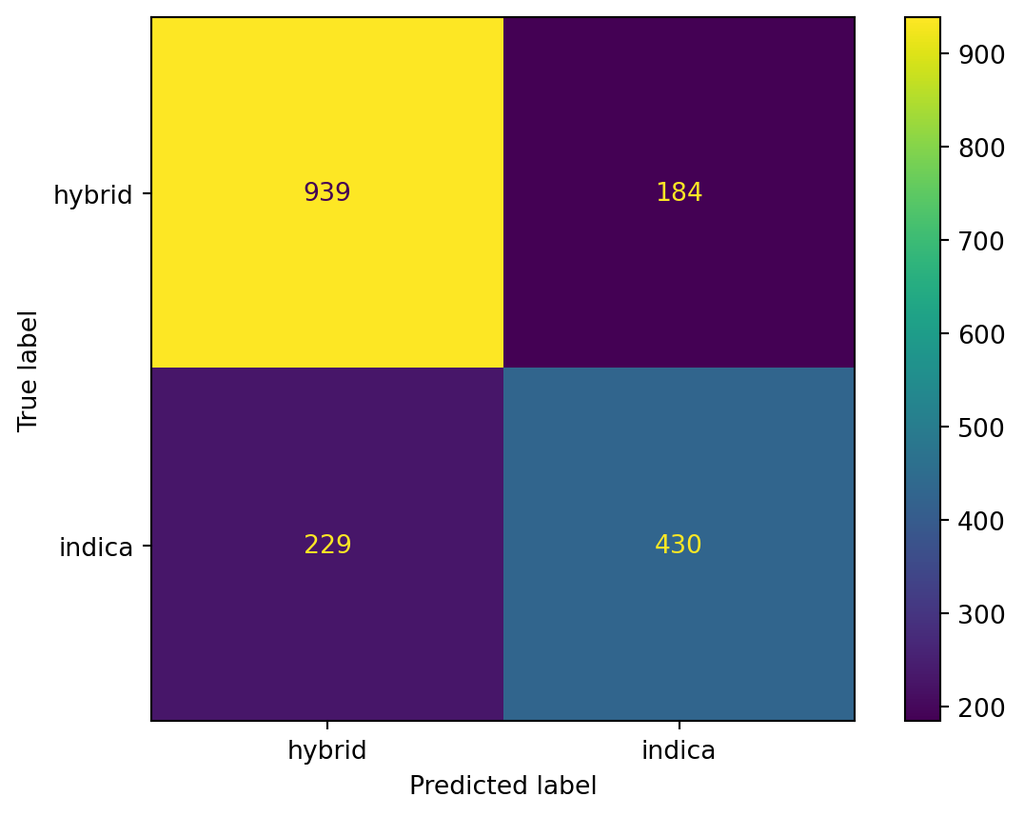

```python
ConfusionMatrixDisplay.from_estimator(logit_ovo2_fitted, X, y)
```

## Q3: Hybrid vs. Sativa

Reduce dataset to only sativa and hybrid types:

```python
cannabis_sat_hyb = cannabis[(cannabis["Type"] == "sativa") | (cannabis["Type"] == "hybrid")]
cannabis_sat_hyb.head()
```

|  | Strain | Type | Rating | Effects | Flavor | Creative | Energetic | Tingly | Euphoric | Relaxed | ... | Fruit | Butter | Pineapple | Tar | Rose | Plum | Pear | indica | sativa | hybrid |
| --- | --- | --- | --- | --- | --- | --- | --- | --- | --- | --- | --- | --- | --- | --- | --- | --- | --- | --- | --- | --- | --- |
| 0 | 100-Og | hybrid | 4.0 | Creative,Energetic,Tingly,Euphoric,Relaxed | Earthy,Sweet,Citrus | 1.0 | 1.0 | 1.0 | 1.0 | 1.0 | ... | 0.0 | 0.0 | 0.0 | 0.0 | 0.0 | 0.0 | 0.0 | 0 | 0 | 1 |
| 1 | 98-White-Widow | hybrid | 4.7 | Relaxed,Aroused,Creative,Happy,Energetic | Flowery,Violet,Diesel | 1.0 | 1.0 | 0.0 | 0.0 | 1.0 | ... | 0.0 | 0.0 | 0.0 | 0.0 | 0.0 | 0.0 | 0.0 | 0 | 0 | 1 |
| 2 | 1024 | sativa | 4.4 | Uplifted,Happy,Relaxed,Energetic,Creative | Spicy/Herbal,Sage,Woody | 1.0 | 1.0 | 0.0 | 0.0 | 1.0 | ... | 0.0 | 0.0 | 0.0 | 0.0 | 0.0 | 0.0 | 0.0 | 0 | 1 | 0 |
| 3 | 13-Dawgs | hybrid | 4.2 | Tingly,Creative,Hungry,Relaxed,Uplifted | Apricot,Citrus,Grapefruit | 1.0 | 0.0 | 1.0 | 0.0 | 1.0 | ... | 0.0 | 0.0 | 0.0 | 0.0 | 0.0 | 0.0 | 0.0 | 0 | 0 | 1 |
| 4 | 24K-Gold | hybrid | 4.6 | Happy,Relaxed,Euphoric,Uplifted,Talkative | Citrus,Earthy,Orange | 0.0 | 0.0 | 0.0 | 1.0 | 1.0 | ... | 0.0 | 0.0 | 0.0 | 0.0 | 0.0 | 0.0 | 0.0 | 0 | 0 | 1 |

5 rows × 72 columns

Define X and y:

```python
X = cannabis_sat_hyb.drop(['Strain', 'Type', 'Effects', 'Flavor', 'indica', 'sativa', 'hybrid'], axis = 1)
y = cannabis_sat_hyb['Type']
```

```python
X.head()
```

|  | Rating | Creative | Energetic | Tingly | Euphoric | Relaxed | Aroused | Happy | Uplifted | Hungry | ... | Ammonia | Minty | Tree | Fruit | Butter | Pineapple | Tar | Rose | Plum | Pear |
| --- | --- | --- | --- | --- | --- | --- | --- | --- | --- | --- | --- | --- | --- | --- | --- | --- | --- | --- | --- | --- | --- |
| 0 | 4.0 | 1.0 | 1.0 | 1.0 | 1.0 | 1.0 | 0.0 | 0.0 | 0.0 | 0.0 | ... | 0.0 | 0.0 | 0.0 | 0.0 | 0.0 | 0.0 | 0.0 | 0.0 | 0.0 | 0.0 |
| 1 | 4.7 | 1.0 | 1.0 | 0.0 | 0.0 | 1.0 | 1.0 | 1.0 | 0.0 | 0.0 | ... | 0.0 | 0.0 | 0.0 | 0.0 | 0.0 | 0.0 | 0.0 | 0.0 | 0.0 | 0.0 |
| 2 | 4.4 | 1.0 | 1.0 | 0.0 | 0.0 | 1.0 | 0.0 | 1.0 | 1.0 | 0.0 | ... | 0.0 | 0.0 | 0.0 | 0.0 | 0.0 | 0.0 | 0.0 | 0.0 | 0.0 | 0.0 |
| 3 | 4.2 | 1.0 | 0.0 | 1.0 | 0.0 | 1.0 | 0.0 | 0.0 | 1.0 | 1.0 | ... | 0.0 | 0.0 | 0.0 | 0.0 | 0.0 | 0.0 | 0.0 | 0.0 | 0.0 | 0.0 |
| 4 | 4.6 | 0.0 | 0.0 | 0.0 | 1.0 | 1.0 | 0.0 | 1.0 | 1.0 | 0.0 | ... | 0.0 | 0.0 | 0.0 | 0.0 | 0.0 | 0.0 | 0.0 | 0.0 | 0.0 | 0.0 |

5 rows × 65 columns

```python
y.head()
```

```
0    hybrid
1    hybrid
2    sativa
3    hybrid
4    hybrid
Name: Type, dtype: object
```

**SVC**

```python
#define parameter space
param_grid = {"preprocessing__scale":[StandardScaler(), MinMaxScaler()],
'svc__C': [0.01, 0.1, 1, 10, 100]}

#perform grid search
svc_model_ovo3 = Pipeline(
  [("preprocessing", preprocessing),
  ("svc", SVC(kernel="linear", probability=True))])

grid_search = GridSearchCV(
    svc_model_ovo3,
    param_grid=param_grid,
    scoring="accuracy",
    cv=5,
    n_jobs = -1
)

grid_search.fit(X, y)
print("Best accuracy score:", grid_search.best_score_)
print("Best params:", grid_search.best_params_)
```

```
Best accuracy score: 0.7473611377232761
Best params: {'preprocessing__scale': MinMaxScaler(), 'svc__C': 1}
```

The best SVC model for this OvR approach is the one using a min-max scaler for the “Rating” variable and a regularization strength value (C) of 1 due to having the largest accuracy score (0.747).

Define best SVC model:

```python
svc_ovo3_final = Pipeline(
  [("preprocessing", preprocessing_min_max),
  ("svc", SVC(kernel="linear", probability=True, C = 1))])

svc_ovo3_fitted = svc_ovo3_final.fit(X, y)
```

Confusion matrix:

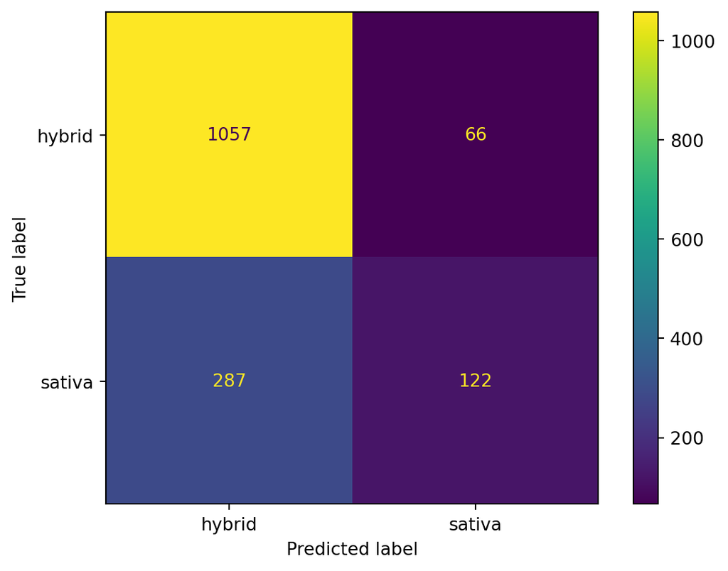

```python
ConfusionMatrixDisplay.from_estimator(svc_ovo3_fitted, X, y)
```

**Logistic Regression**

```python
#define parameter space
param_grid = {"preprocessing__scale":[StandardScaler(), MinMaxScaler()],
"logit__penalty":["l1", "l2", "elasticnet"],
"logit__C":[0.001, 0.01, 0.1, 1, 10],
"logit__l1_ratio": [0.0, 0.25, 0.5, 0.75, 1.0]}

#perform grid search
logit_model_ovo3 = Pipeline(
  [("preprocessing", preprocessing),
  ("logit", LogisticRegression(solver = "saga", max_iter = 5000, random_state=321))])

grid_search = GridSearchCV(
    logit_model_ovo3,
    param_grid=param_grid,
    scoring="accuracy",
    cv=5,
    n_jobs = -1
)

grid_search.fit(X, y)
print("Best accuracy score:", grid_search.best_score_)
print("Best params:", grid_search.best_params_)
```

```
Best accuracy score: 0.7539290200336378
Best params: {'logit__C': 0.1, 'logit__l1_ratio': 0.0, 'logit__penalty': 'l1', 'preprocessing__scale': MinMaxScaler()}
```

The best logistic regression model for this OvR approach is the one using a min-max scaler for the “Rating” variable and a lasso penalty with a regularization strength value (C) of 0.1 due to having the largest accuracy score (0.754).

Define best logistic regression model:

```python
logit_ovo3_final = Pipeline(
  [("preprocessing", preprocessing_min_max),
  ("logit", LogisticRegression(C = 0.1, penalty="l1", solver = "saga", random_state=321, max_iter=5000))])

logit_ovo3_fitted = logit_ovo3_final.fit(X, y)
```

Confusion matrix:

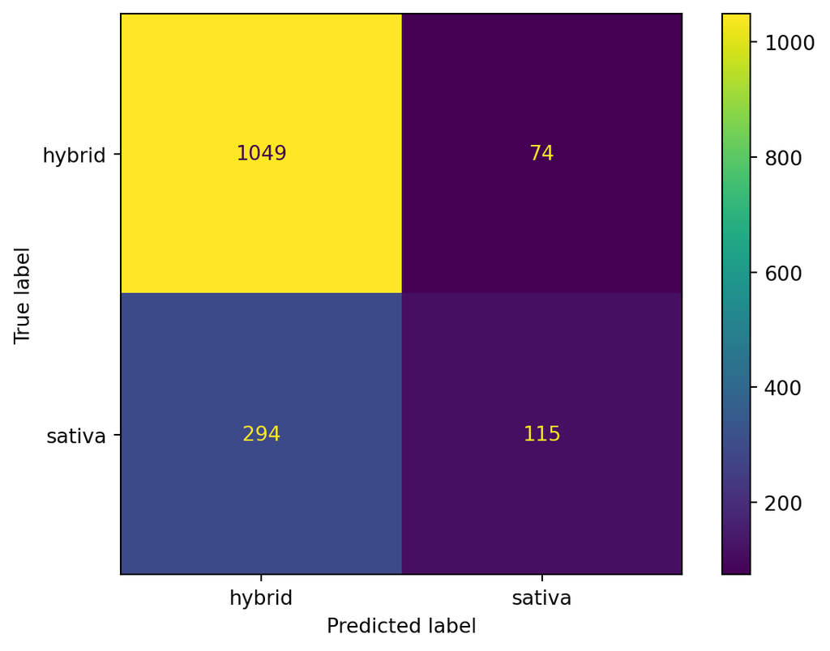

```python
ConfusionMatrixDisplay.from_estimator(logit_ovo3_fitted, X, y)
```

## Q4

The indica vs. sativa specification for the logistic regression model performed the best due to having the largest accuracy score. The hybrid vs. sativa specification for the SVC model performed the worst due to having the smallest accuracy score. It makes intuitive sense that logistic model was better able to identify indica types from sativa types than indica/sativa types from the hybrid type because indica and sativa are distinct strains while hybrid types are cross-bred indica and sativa strains, therefore making it more difficult to differentiate between a strain that is purely indica/sativa and a strain that contains a percentage of indica/sativa in it. Additionally, the sativa vs. not sativa OvR model performed the worst in terms of F1 score in the previous section, so it makes sense that the hybrid vs. sativa OvO model also performed the worst in this section. Although the SVC model did not perform the best, it is noteworthy that this model performed much better for the OvO specifications in this section than the OvR specifications in the previous section. This is likely due to the fact that SVC’s goal is to maximize the margin between two classes, so is therefore better at differentiating between classes rather than accurately identifying values of the target variable for each observation.

## Q5

Logistic Regression: According to the documentation of the `LogisticRegression()` function, it appears that the logistic regression function would automatically take an OvR approach, as the default method of the `multi_class` argument automatically select `ovr` as the classification method.

SVC: According to the documentation of the `SVC()` function, the default method to train the SVC model is OvO. Therefore, the SVC model would automatically take an OvO approach.